# Body Fat Prediction: EDA and Predictive Modelling

Authors

HAGIU I. PAULA-CĂTĂLINA

CONSTANTINESCU A. CEZAR

IRIMIA L. NICOLAE

Published

April 8, 2026

# 1 Non-Graphical Exploratory Data Analysis

A thorough non-graphical exploratory data analysis (EDA) of the BodyFat dataset, including structural inspection and identification of leakage variables. This section covers data shape, numeric summaries, and the critical discovery that `Density` is mathematically derived from `BodyFat` via Siri’s equation and must be excluded from modeling.

 ## Objective

This report performs a thorough non-graphical exploratory data analysis (EDA) of the BodyFat dataset.

Key requirement addressed immediately: - All columns are numeric. - `Density` is a direct leakage variable because `BodyFat` is mathematically derived from it using Siri’s equation:

$$\text{BodyFat} = \frac{495}{\text{Density}} - 450$$

## 1.1 Setup and Data Loading

```r
library(tidyverse)

bodyfat_raw <- read_csv("data/bodyfat.csv", show_col_types = FALSE)
```

## 1.2 Data Structure Inspection (glimpse and summary)

```r
# Compact structure view
bodyfat_raw %>% glimpse()
```

```
Rows: 252
Columns: 15
$ Density <dbl> 1.0708, 1.0853, 1.0414, 1.0751, 1.0340, 1.0502, 1.0549, 1.0704…
$ BodyFat <dbl> 12.3, 6.1, 25.3, 10.4, 28.7, 20.9, 19.2, 12.4, 4.1, 11.7, 7.1,…
$ Age     <dbl> 23, 22, 22, 26, 24, 24, 26, 25, 25, 23, 26, 27, 32, 30, 35, 35…
$ Weight  <dbl> 154.25, 173.25, 154.00, 184.75, 184.25, 210.25, 181.00, 176.00…
$ Height  <dbl> 67.75, 72.25, 66.25, 72.25, 71.25, 74.75, 69.75, 72.50, 74.00,…
$ Neck    <dbl> 36.2, 38.5, 34.0, 37.4, 34.4, 39.0, 36.4, 37.8, 38.1, 42.1, 38…
$ Chest   <dbl> 93.1, 93.6, 95.8, 101.8, 97.3, 104.5, 105.1, 99.6, 100.9, 99.6…
$ Abdomen <dbl> 85.2, 83.0, 87.9, 86.4, 100.0, 94.4, 90.7, 88.5, 82.5, 88.6, 8…
$ Hip     <dbl> 94.5, 98.7, 99.2, 101.2, 101.9, 107.8, 100.3, 97.1, 99.9, 104.…
$ Thigh   <dbl> 59.0, 58.7, 59.6, 60.1, 63.2, 66.0, 58.4, 60.0, 62.9, 63.1, 59…
$ Knee    <dbl> 37.3, 37.3, 38.9, 37.3, 42.2, 42.0, 38.3, 39.4, 38.3, 41.7, 39…
$ Ankle   <dbl> 21.9, 23.4, 24.0, 22.8, 24.0, 25.6, 22.9, 23.2, 23.8, 25.0, 25…
$ Biceps  <dbl> 32.0, 30.5, 28.8, 32.4, 32.2, 35.7, 31.9, 30.5, 35.9, 35.6, 32…
$ Forearm <dbl> 27.4, 28.9, 25.2, 29.4, 27.7, 30.6, 27.8, 29.0, 31.1, 30.0, 29…
$ Wrist   <dbl> 17.1, 18.2, 16.6, 18.2, 17.7, 18.8, 17.7, 18.8, 18.2, 19.2, 18…
```

```r
# Numeric summaries for each feature
summary(bodyfat_raw)
```

```
    Density         BodyFat           Age            Weight
 Min.   :0.995   Min.   : 0.00   Min.   :22.00   Min.   :118.5
 1st Qu.:1.041   1st Qu.:12.47   1st Qu.:35.75   1st Qu.:159.0
 Median :1.055   Median :19.20   Median :43.00   Median :176.5
 Mean   :1.056   Mean   :19.15   Mean   :44.88   Mean   :178.9
 3rd Qu.:1.070   3rd Qu.:25.30   3rd Qu.:54.00   3rd Qu.:197.0
 Max.   :1.109   Max.   :47.50   Max.   :81.00   Max.   :363.1
     Height           Neck           Chest           Abdomen
 Min.   :29.50   Min.   :31.10   Min.   : 79.30   Min.   : 69.40
 1st Qu.:68.25   1st Qu.:36.40   1st Qu.: 94.35   1st Qu.: 84.58
 Median :70.00   Median :38.00   Median : 99.65   Median : 90.95
 Mean   :70.15   Mean   :37.99   Mean   :100.82   Mean   : 92.56
 3rd Qu.:72.25   3rd Qu.:39.42   3rd Qu.:105.38   3rd Qu.: 99.33
 Max.   :77.75   Max.   :51.20   Max.   :136.20   Max.   :148.10
      Hip            Thigh            Knee           Ankle          Biceps
 Min.   : 85.0   Min.   :47.20   Min.   :33.00   Min.   :19.1   Min.   :24.80
 1st Qu.: 95.5   1st Qu.:56.00   1st Qu.:36.98   1st Qu.:22.0   1st Qu.:30.20
 Median : 99.3   Median :59.00   Median :38.50   Median :22.8   Median :32.05
 Mean   : 99.9   Mean   :59.41   Mean   :38.59   Mean   :23.1   Mean   :32.27
 3rd Qu.:103.5   3rd Qu.:62.35   3rd Qu.:39.92   3rd Qu.:24.0   3rd Qu.:34.33
 Max.   :147.7   Max.   :87.30   Max.   :49.10   Max.   :33.9   Max.   :45.00
    Forearm          Wrist
 Min.   :21.00   Min.   :15.80
 1st Qu.:27.30   1st Qu.:17.60
 Median :28.70   Median :18.30
 Mean   :28.66   Mean   :18.23
 3rd Qu.:30.00   3rd Qu.:18.80
 Max.   :34.90   Max.   :21.40
```

### 1.2.1 Immediate Leakage Check for Density

```r
# Verify Siri equation numerically against observed BodyFat values
bodyfat_with_check <- bodyfat_raw %>%
  mutate(
    BodyFat_from_Density = 495 / Density - 450,
    Leakage_abs_error = abs(BodyFat - BodyFat_from_Density)
  )

bodyfat_with_check %>%
  summarise(
    max_abs_error = max(Leakage_abs_error),
    mean_abs_error = mean(Leakage_abs_error),
    min_abs_error = min(Leakage_abs_error)
  )
```

```
# A tibble: 1 × 3
  max_abs_error mean_abs_error min_abs_error
          <dbl>          <dbl>         <dbl>
1          17.0          0.173     0.0000553
```

```r
bodyfat <- bodyfat_raw %>% select(-Density)
```

## 1.3 Dataset Dimensions, Types, and Duplicates

```r
# Shape
c(rows = nrow(bodyfat_raw), columns = ncol(bodyfat_raw))
```

```
   rows columns
    252      15
```

```r
# Confirm all columns are numeric in raw data
sapply(bodyfat_raw, class)
```

```
  Density   BodyFat       Age    Weight    Height      Neck     Chest   Abdomen
"numeric" "numeric" "numeric" "numeric" "numeric" "numeric" "numeric" "numeric"
      Hip     Thigh      Knee     Ankle    Biceps   Forearm     Wrist
"numeric" "numeric" "numeric" "numeric" "numeric" "numeric" "numeric"
```

```r
# Duplicate rows
bodyfat_raw %>%
  summarise(duplicate_rows = sum(duplicated(.)))
```

```
# A tibble: 1 × 1
  duplicate_rows
           <int>
1              0
```

```r
# Summary table for all original features (including Density for EDA completeness)
summary_table_all_features <- map_dfr(names(bodyfat_raw), function(v) {
  x <- bodyfat_raw[[v]]
  mean_x <- mean(x, na.rm = TRUE)
  sd_x <- sd(x, na.rm = TRUE)

  tibble(
    feature = v,
    mean = mean_x,
    median = median(x, na.rm = TRUE),
    sd = sd_x,
    iqr = IQR(x, na.rm = TRUE),
    cv = ifelse(mean_x == 0, NA_real_, sd_x / mean_x)
  )
})

summary_table_all_features
```

```
# A tibble: 15 × 6
   feature   mean median      sd     iqr     cv
   <chr>    <dbl>  <dbl>   <dbl>   <dbl>  <dbl>
 1 Density   1.06   1.05  0.0190  0.0290 0.0180
 2 BodyFat  19.2   19.2   8.37   12.8    0.437
 3 Age      44.9   43    12.6    18.2    0.281
 4 Weight  179.   176.   29.4    38      0.164
 5 Height   70.1   70     3.66    4      0.0522
 6 Neck     38.0   38     2.43    3.02   0.0640
 7 Chest   101.    99.6   8.43   11.0    0.0836
 8 Abdomen  92.6   91.0  10.8    14.8    0.117
 9 Hip      99.9   99.3   7.16    8.03   0.0717
10 Thigh    59.4   59     5.25    6.35   0.0884
11 Knee     38.6   38.5   2.41    2.95   0.0625
12 Ankle    23.1   22.8   1.69    2      0.0734
13 Biceps   32.3   32.0   3.02    4.12   0.0936
14 Forearm  28.7   28.7   2.02    2.7    0.0705
15 Wrist    18.2   18.3   0.934   1.2    0.0512
```

## 1.5 Missing Value Analysis

```r
# Missingness by feature (count and percent)
missing_by_feature <- bodyfat_raw %>%
  summarise(across(everything(), ~ sum(is.na(.)))) %>%
  pivot_longer(
    cols = everything(),
    names_to = "feature",
    values_to = "missing_n"
  ) %>%
  mutate(missing_pct = 100 * missing_n / nrow(bodyfat_raw)) %>%
  arrange(desc(missing_n), feature)

missing_by_feature
```

```
# A tibble: 15 × 3
   feature missing_n missing_pct
   <chr>       <int>       <dbl>
 1 Abdomen         0           0
 2 Age             0           0
 3 Ankle           0           0
 4 Biceps          0           0
 5 BodyFat         0           0
 6 Chest           0           0
 7 Density         0           0
 8 Forearm         0           0
 9 Height          0           0
10 Hip             0           0
11 Knee            0           0
12 Neck            0           0
13 Thigh           0           0
14 Weight          0           0
15 Wrist           0           0
```

```r
# Missingness by observation (row-wise NA count)
row_missing <- bodyfat_raw %>%
  mutate(row_id = row_number(), missing_n = rowSums(is.na(across(everything())))) %>%
  select(row_id, missing_n)

row_missing %>%
  summarise(
    complete_rows = sum(missing_n == 0),
    incomplete_rows = sum(missing_n > 0),
    pct_complete_rows = 100 * mean(missing_n == 0),
    max_missing_in_a_row = max(missing_n)
  )
```

```
# A tibble: 1 × 4
  complete_rows incomplete_rows pct_complete_rows max_missing_in_a_row
          <int>           <int>             <dbl>                <dbl>
1           252               0               100                    0
```

```r
# Distribution of row-level missingness severity
row_missing %>%
  count(missing_n, name = "row_count") %>%
  arrange(missing_n)
```

```
# A tibble: 1 × 2
  missing_n row_count
      <dbl>     <int>
1         0       252
```

## 1.6 Implausible Values and Data Quality Flags

```r
# Flag records that are statistically and/or physically implausible
implausible_rows <- bodyfat_raw %>%
  mutate(row_id = row_number()) %>%
  filter(BodyFat <= 1 | Height < 55)

implausible_rows %>%
  select(row_id, BodyFat, Height, Age, Weight, Density, everything())
```

```
# A tibble: 3 × 16
  row_id BodyFat Height   Age Weight Density  Neck Chest Abdomen   Hip Thigh
   <int>   <dbl>  <dbl> <dbl>  <dbl>   <dbl> <dbl> <dbl>   <dbl> <dbl> <dbl>
1     42    32.9   29.5    44   205     1.02  36.6 106     104.  116.   70.6
2    172     0.7   65.5    35   126.    1.10  34    90.8    75    89.2  50
3    182     0     68      40   118.    1.11  33.8  79.3    69.4  85    47.2
# ℹ 5 more variables: Knee <dbl>, Ankle <dbl>, Biceps <dbl>, Forearm <dbl>,
#   Wrist <dbl>
```

```r
# Compact report of the two specific issues requested
implausible_summary <- bodyfat_raw %>%
  mutate(row_id = row_number()) %>%
  summarise(
    bodyfat_zero_row = row_id[which.min(BodyFat)],
    bodyfat_zero_value = min(BodyFat, na.rm = TRUE),
    low_height_row = row_id[which.min(Height)],
    low_height_value = min(Height, na.rm = TRUE)
  )

implausible_summary
```

```
# A tibble: 1 × 4
  bodyfat_zero_row bodyfat_zero_value low_height_row low_height_value
             <int>              <dbl>          <int>            <dbl>
1              182                  0             42             29.5
```

Interpretation and treatment recommendation: - The row with `BodyFat` approximately 0% (exactly 0.0 in this file) is biologically very unlikely for this population and should be treated as a suspect observation. - The row with `Height = 29.5` inches is not plausible for an adult male body-composition dataset and is most likely a data entry/coding error (for example, a dropped leading digit such as 69.5). - Decision guideline: - If source records can be audited, correct clear typos (preferred). - If audit is not possible, mark these values as invalid (`NA`) and use robust handling/imputation, or remove the affected row(s) in sensitivity analysis. - Do not keep these records unchanged in a final modeling dataset; they are better treated as probable data errors than natural outliers.

## 1.7 Outlier Diagnostics by IQR Rule (Non-Graphical)

```r
outlier_counts <- map_dfr(names(bodyfat), function(v) {
  x <- bodyfat[[v]]
  q1 <- quantile(x, 0.25, na.rm = TRUE)
  q3 <- quantile(x, 0.75, na.rm = TRUE)
  iqr <- q3 - q1
  lower <- q1 - 1.5 * iqr
  upper <- q3 + 1.5 * iqr

  tibble(
    variable = v,
    lower_bound = lower,
    upper_bound = upper,
    outlier_n = sum(x < lower | x > upper, na.rm = TRUE),
    outlier_pct = 100 * mean(x < lower | x > upper, na.rm = TRUE)
  )
})

outlier_counts %>% arrange(desc(outlier_n))
```

```
# A tibble: 14 × 5
   variable lower_bound upper_bound outlier_n outlier_pct
   <chr>          <dbl>       <dbl>     <int>       <dbl>
 1 Forearm        23.2         34.0         5       1.98
 2 Thigh          46.5         71.9         4       1.59
 3 Wrist          15.8         20.6         4       1.59
 4 Neck           31.9         44.0         3       1.19
 5 Abdomen        62.4        121.          3       1.19
 6 Hip            83.5        116.          3       1.19
 7 Knee           32.6         44.3         3       1.19
 8 Ankle          19           27           3       1.19
 9 Weight        102          254           2       0.794
10 Chest          77.8        122.          2       0.794
11 BodyFat        -6.76        44.5         1       0.397
12 Height         62.2         78.2         1       0.397
13 Biceps         24.0         40.5         1       0.397
14 Age             8.38        81.4         0       0
```

## 1.8 Correlation Analysis (No Plots)

```r
# Correlation matrix after dropping Density
cor_matrix <- cor(bodyfat, use = "pairwise.complete.obs")
cor_matrix
```

```
            BodyFat         Age      Weight      Height      Neck     Chest
BodyFat  1.00000000  0.29145844  0.61241400 -0.08949538 0.4905919 0.7026203
Age      0.29145844  1.00000000 -0.01274609 -0.17164514 0.1135052 0.1764497
Weight   0.61241400 -0.01274609  1.00000000  0.30827854 0.8307162 0.8941905
Height  -0.08949538 -0.17164514  0.30827854  1.00000000 0.2537099 0.1348918
Neck     0.49059185  0.11350519  0.83071622  0.25370988 1.0000000 0.7848350
Chest    0.70262034  0.17644968  0.89419052  0.13489181 0.7848350 1.0000000
Abdomen  0.81343228  0.23040942  0.88799494  0.08781291 0.7540774 0.9158277
Hip      0.62520092 -0.05033212  0.94088412  0.17039426 0.7349579 0.8294199
Thigh    0.55960753 -0.20009576  0.86869354  0.14843561 0.6956973 0.7298586
Knee     0.50866524  0.01751569  0.85316739  0.28605321 0.6724050 0.7194964
Ankle    0.26596977 -0.10505810  0.61368542  0.26474369 0.4778924 0.4829879
Biceps   0.49327113 -0.04116212  0.80041593  0.20781557 0.7311459 0.7279075
Forearm  0.36138690 -0.08505555  0.63030143  0.22864922 0.6236603 0.5801727
Wrist    0.34657486  0.21353062  0.72977489  0.32206533 0.7448264 0.6601623
           Abdomen         Hip      Thigh       Knee      Ankle      Biceps
BodyFat 0.81343228  0.62520092  0.5596075 0.50866524  0.2659698  0.49327113
Age     0.23040942 -0.05033212 -0.2000958 0.01751569 -0.1050581 -0.04116212
Weight  0.88799494  0.94088412  0.8686935 0.85316739  0.6136854  0.80041593
Height  0.08781291  0.17039426  0.1484356 0.28605321  0.2647437  0.20781557
Neck    0.75407737  0.73495788  0.6956973 0.67240498  0.4778924  0.73114592
Chest   0.91582767  0.82941992  0.7298586 0.71949640  0.4829879  0.72790748
Abdomen 1.00000000  0.87406618  0.7666239 0.73717888  0.4532227  0.68498272
Hip     0.87406618  1.00000000  0.8964098 0.82347262  0.5583868  0.73927252
Thigh   0.76662393  0.89640979  1.0000000 0.79917030  0.5397971  0.76147745
Knee    0.73717888  0.82347262  0.7991703 1.00000000  0.6116082  0.67870883
Ankle   0.45322269  0.55838682  0.5397971 0.61160820  1.0000000  0.48485454
Biceps  0.68498272  0.73927252  0.7614774 0.67870883  0.4848545  1.00000000
Forearm 0.50331609  0.54501412  0.5668422 0.55589819  0.4190500  0.67825513
Wrist   0.61983243  0.63008954  0.5586848 0.66450729  0.5661946  0.63212642
            Forearm     Wrist
BodyFat  0.36138690 0.3465749
Age     -0.08505555 0.2135306
Weight   0.63030143 0.7297749
Height   0.22864922 0.3220653
Neck     0.62366027 0.7448264
Chest    0.58017273 0.6601623
Abdomen  0.50331609 0.6198324
Hip      0.54501412 0.6300895
Thigh    0.56684218 0.5586848
Knee     0.55589819 0.6645073
Ankle    0.41904999 0.5661946
Biceps   0.67825513 0.6321264
Forearm  1.00000000 0.5855883
Wrist    0.58558825 1.0000000
```

```r
# Rank strongest absolute correlations with BodyFat
target_cor <- tibble(
  variable = setdiff(colnames(bodyfat), "BodyFat"),
  cor_with_bodyfat = cor_matrix[setdiff(colnames(bodyfat), "BodyFat"), "BodyFat"]
) %>%
  mutate(abs_cor = abs(cor_with_bodyfat)) %>%
  arrange(desc(abs_cor))

target_cor
```

```
# A tibble: 13 × 3
   variable cor_with_bodyfat abs_cor
   <chr>               <dbl>   <dbl>
 1 Abdomen            0.813   0.813
 2 Chest              0.703   0.703
 3 Hip                0.625   0.625
 4 Weight             0.612   0.612
 5 Thigh              0.560   0.560
 6 Knee               0.509   0.509
 7 Biceps             0.493   0.493
 8 Neck               0.491   0.491
 9 Forearm            0.361   0.361
10 Wrist              0.347   0.347
11 Age                0.291   0.291
12 Ankle              0.266   0.266
13 Height            -0.0895  0.0895
```

```r
# Top overall pairwise correlations (excluding self-pairs and duplicates)
cor_long <- as.data.frame(as.table(cor_matrix)) %>%
  as_tibble() %>%
  rename(var1 = Var1, var2 = Var2, correlation = Freq) %>%
  filter(var1 < var2) %>%
  mutate(abs_correlation = abs(correlation)) %>%
  arrange(desc(abs_correlation))

head(cor_long, 15)
```

```
# A tibble: 0 × 4
# ℹ 4 variables: var1 <fct>, var2 <fct>, correlation <dbl>,
#   abs_correlation <dbl>
```

```r
# All feature pairs with strong linear association (|correlation| > 0.8)
high_cor_pairs <- cor_long %>%
  filter(abs_correlation > 0.8) %>%
  arrange(desc(abs_correlation))

high_cor_pairs
```

```
# A tibble: 0 × 4
# ℹ 4 variables: var1 <fct>, var2 <fct>, correlation <dbl>,
#   abs_correlation <dbl>
```

```r
# Focus on circumference clusters requested in the assignment
focus_pairs <- tibble(
  var1 = c("Chest", "Chest", "Abdomen", "Knee", "Knee", "Ankle"),
  var2 = c("Abdomen", "Hip", "Hip", "Ankle", "Wrist", "Wrist")
) %>%
  mutate(
    correlation = map2_dbl(var1, var2, ~ cor_matrix[.x, .y]),
    abs_correlation = abs(correlation)
  ) %>%
  mutate(over_0_8 = abs_correlation > 0.8)

focus_pairs
```

```
# A tibble: 6 × 5
  var1    var2    correlation abs_correlation over_0_8
  <chr>   <chr>         <dbl>           <dbl> <lgl>
1 Chest   Abdomen       0.916           0.916 TRUE
2 Chest   Hip           0.829           0.829 TRUE
3 Abdomen Hip           0.874           0.874 TRUE
4 Knee    Ankle         0.612           0.612 FALSE
5 Knee    Wrist         0.665           0.665 FALSE
6 Ankle   Wrist         0.566           0.566 FALSE
```

## 1.9 Distribution Shape Indicators (Skewness/Kurtosis Without Plots)

```r
# Helper functions avoid extra package dependencies
sample_skewness <- function(x) {
  x <- x[!is.na(x)]
  n <- length(x)
  if (n < 3) return(NA_real_)
  m <- mean(x)
  s <- sd(x)
  if (s == 0) return(0)
  n / ((n - 1) * (n - 2)) * sum(((x - m) / s)^3)
}

sample_excess_kurtosis <- function(x) {
  x <- x[!is.na(x)]
  n <- length(x)
  if (n < 4) return(NA_real_)
  m <- mean(x)
  s <- sd(x)
  if (s == 0) return(0)
  term1 <- (n * (n + 1)) / ((n - 1) * (n - 2) * (n - 3)) * sum(((x - m) / s)^4)
  term2 <- (3 * (n - 1)^2) / ((n - 2) * (n - 3))
  term1 - term2
}

shape_stats <- map_dfr(names(bodyfat), function(v) {
  x <- bodyfat[[v]]
  tibble(
    variable = v,
    skewness = sample_skewness(x),
    excess_kurtosis = sample_excess_kurtosis(x)
  )
})

shape_stats %>% arrange(desc(abs(skewness)))
```

```
# A tibble: 14 × 3
   variable skewness excess_kurtosis
   <chr>       <dbl>           <dbl>
 1 Height     -5.38           59.5
 2 Ankle       2.26           11.9
 3 Hip         1.50            7.47
 4 Weight      1.21            5.27
 5 Abdomen     0.838           2.25
 6 Thigh       0.821           2.67
 7 Chest       0.682           0.987
 8 Neck        0.553           2.72
 9 Knee        0.517           1.06
10 Biceps      0.286           0.498
11 Age         0.284          -0.416
12 Wrist       0.282           0.396
13 Forearm    -0.219           0.866
14 BodyFat     0.146          -0.334
```

# 2 Distribution Analysis

Visualization of the distribution of the target variable (`BodyFat`) and all numeric predictors through histograms and density plots. This section provides insights into the shape, spread, and outliers of each variable in the dataset.

 ## Objective

This report visualizes the distribution of the target variable and the numeric predictors in the BodyFat dataset.

`Density` is omitted from the predictor plots because it is a leakage variable, not a realistic modeling feature.

## 2.1 Setup and Data Loading

```r
library(tidyverse)

bodyfat_raw <- read_csv("data/bodyfat.csv", show_col_types = FALSE)
bodyfat_model <- bodyfat_raw %>% select(-Density)

circumference_vars <- c("Neck", "Chest", "Abdomen", "Hip", "Thigh", "Knee", "Ankle", "Biceps", "Forearm", "Wrist")
body_vars <- bodyfat_model %>% select(BodyFat, all_of(setdiff(names(bodyfat_model), c("BodyFat", circumference_vars))))
```

## 2.2 BodyFat Distribution

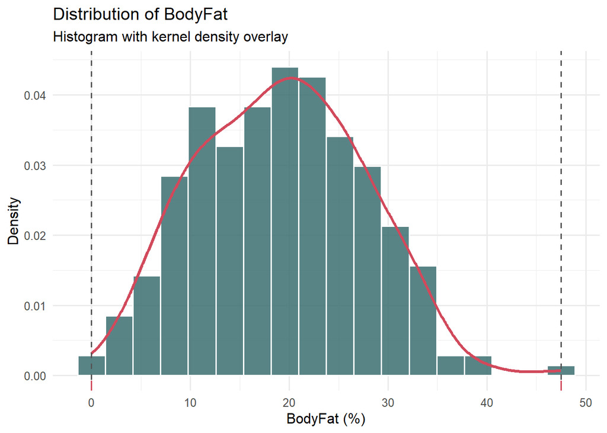

```r
bodyfat_extremes <- bodyfat_raw %>%
  mutate(row_id = row_number()) %>%
  filter(BodyFat == min(BodyFat, na.rm = TRUE) | BodyFat == max(BodyFat, na.rm = TRUE))

bodyfat_plot <- ggplot(bodyfat_raw, aes(x = BodyFat)) +
  geom_histogram(aes(y = after_stat(density)), bins = 18, fill = "#3C6E71", color = "white", alpha = 0.85) +
  geom_density(color = "#D1495B", linewidth = 1.1, adjust = 1.05) +
  geom_vline(xintercept = c(min(bodyfat_raw$BodyFat, na.rm = TRUE), max(bodyfat_raw$BodyFat, na.rm = TRUE)),
             linetype = "dashed", color = "#555555") +
  geom_rug(data = bodyfat_extremes, aes(x = BodyFat), inherit.aes = FALSE, sides = "b", color = "#D1495B") +
  labs(
    title = "Distribution of BodyFat",
    subtitle = "Histogram with kernel density overlay",
    x = "BodyFat (%)",
    y = "Density"
  ) +
  theme_minimal(base_size = 12)

bodyfat_plot
```

The BodyFat distribution spans from the observed minimum of about 0% to the mid-40s. It is concentrated in the lower-to-mid teens and twenties, with a longer right tail than left tail. The near-zero observation is unusual and should be treated as a potential data-quality issue rather than a typical value.

## 2.3 Body Circumference Measurements

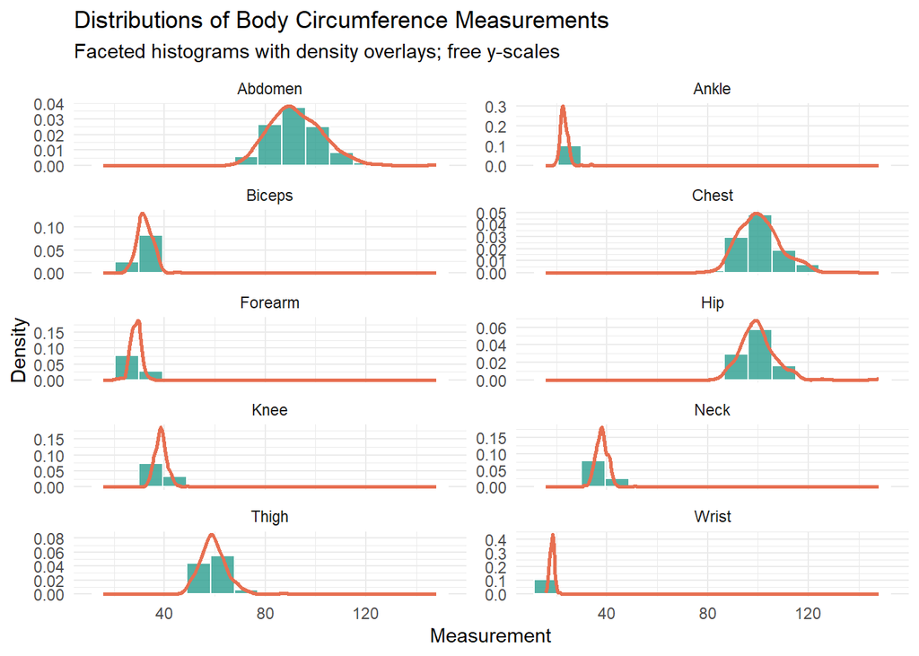

```r
circumference_long <- bodyfat_model %>%
  select(all_of(circumference_vars)) %>%
  pivot_longer(everything(), names_to = "feature", values_to = "value")

circumference_plot <- ggplot(circumference_long, aes(x = value)) +
  geom_histogram(aes(y = after_stat(density)), bins = 15, fill = "#2A9D8F", color = "white", alpha = 0.8) +
  geom_density(color = "#E76F51", linewidth = 0.9, adjust = 1.0) +
  facet_wrap(~ feature, scales = "free_y", ncol = 2) +
  labs(
    title = "Distributions of Body Circumference Measurements",
    subtitle = "Faceted histograms with density overlays; free y-scales",
    x = "Measurement",
    y = "Density"
  ) +
  theme_minimal(base_size = 11)

circumference_plot
```

The torso measurements, especially Chest, Abdomen, and Hip, tend to be wider and more right-skewed, reflecting body-size variation in the sample. The smaller limb and wrist measures are more tightly clustered, with relatively narrower spreads. Free y-scales make the differences in shape and dispersion easier to compare across variables.

## 2.4 Faceted Box Plots for All Modeling Features

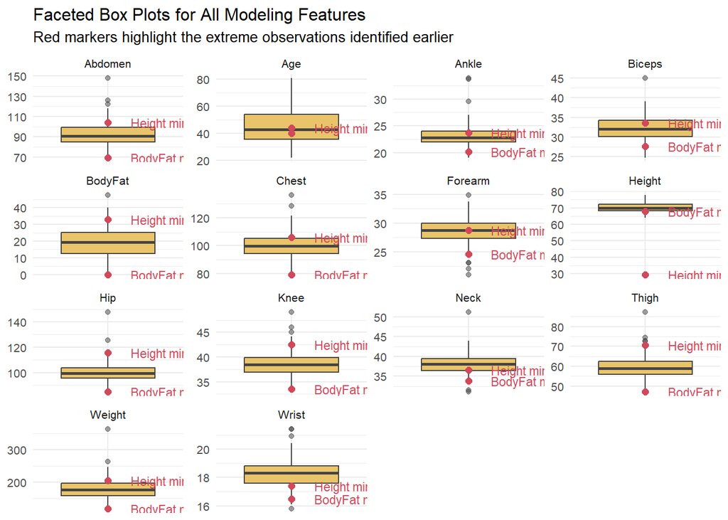

```r
all_model_long <- bodyfat_model %>%
  pivot_longer(everything(), names_to = "feature", values_to = "value")

extreme_rows <- bodyfat_raw %>%
  mutate(row_id = row_number(),
         flag = case_when(
           BodyFat == min(BodyFat, na.rm = TRUE) ~ "BodyFat minimum",
           Height == min(Height, na.rm = TRUE) ~ "Height minimum",
           TRUE ~ NA_character_
         )) %>%
  filter(!is.na(flag))

extreme_long <- extreme_rows %>%
  pivot_longer(-c(row_id, flag), names_to = "feature", values_to = "value") %>%
  filter(feature != "Density")

boxplot_plot <- ggplot(all_model_long, aes(x = "", y = value)) +
  geom_boxplot(fill = "#E9C46A", color = "#444444", outlier.alpha = 0.5) +
  geom_point(
    data = extreme_long,
    aes(x = "", y = value),
    inherit.aes = FALSE,
    color = "#D1495B",
    size = 2
  ) +
  geom_text(
    data = extreme_long,
    aes(x = "", y = value, label = paste0(flag, " (row ", row_id, ")")),
    inherit.aes = FALSE,
    nudge_x = 0.18,
    hjust = 0,
    color = "#D1495B",
    size = 3,
    check_overlap = TRUE
  ) +
  facet_wrap(~ feature, scales = "free_y", ncol = 4) +
  labs(
    title = "Faceted Box Plots for All Modeling Features",
    subtitle = "Red markers highlight the extreme observations identified earlier",
    x = NULL,
    y = NULL
  ) +
  theme_minimal(base_size = 10) +
  theme(axis.text.x = element_blank(), axis.ticks.x = element_blank())

boxplot_plot
```

Most variables show at least mild skewness and a few high-end outliers, which is typical for body-measurement data. The red labels identify the two problematic records from the earlier EDA: the near-zero BodyFat value and the unusually low Height value. Those points stand out clearly and should be reviewed as likely data errors.

## 2.5 Age, Weight, and Height

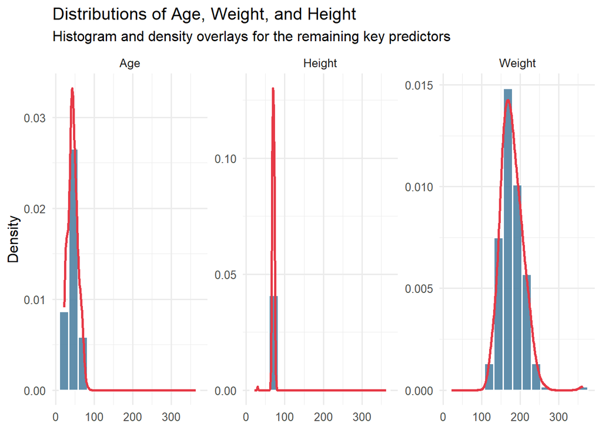

```r
age_weight_height_long <- bodyfat_model %>%
  select(Age, Weight, Height) %>%
  pivot_longer(everything(), names_to = "feature", values_to = "value")

age_weight_height_plot <- ggplot(age_weight_height_long, aes(x = value)) +
  geom_histogram(aes(y = after_stat(density)), bins = 15, fill = "#457B9D", color = "white", alpha = 0.85) +
  geom_density(color = "#E63946", linewidth = 1.0, adjust = 1.05) +
  facet_wrap(~ feature, scales = "free_y", nrow = 1) +
  labs(
    title = "Distributions of Age, Weight, and Height",
    subtitle = "Histogram and density overlays for the remaining key predictors",
    x = NULL,
    y = "Density"
  ) +
  theme_minimal(base_size = 12)

age_weight_height_plot
```

Age is typically moderately spread and often slightly right-skewed, Weight is more dispersed with a stronger right tail, and Height is usually fairly concentrated except for the implausibly low observation. Together, these variables show a mix of broad spread and isolated extremes, so they are worth checking for data quality and scale differences before modeling.

# 3 Body Regions and Body Fat Profiles

Comparative analysis of body measurements across different body fat percentage levels. The dataset is divided into three equal-sized groups (terciles) based on body fat percentage, enabling investigation of patterns in body circumference measurements and their relationship to overall body fat composition.

 ## Introduction

This exploratory data analysis examines how body measurements vary across different body fat percentage levels. The analysis divides the 252 men in the dataset into three equal-sized groups (terciles) based on body fat percentage, then investigates patterns in body circumference measurements across these groups.

## 3.1 Data Preparation

```r
# Load required libraries
library(tidyverse)
library(ggplot2)
library(GGally)
library(gridExtra)
library(scales)

# Load the dataset
bodyfat <- read.csv("data/bodyfat.csv")

# Display first few rows
head(bodyfat)
```

```
  Density BodyFat Age Weight Height Neck Chest Abdomen   Hip Thigh Knee Ankle
1  1.0708    12.3  23 154.25  67.75 36.2  93.1    85.2  94.5  59.0 37.3  21.9
2  1.0853     6.1  22 173.25  72.25 38.5  93.6    83.0  98.7  58.7 37.3  23.4
3  1.0414    25.3  22 154.00  66.25 34.0  95.8    87.9  99.2  59.6 38.9  24.0
4  1.0751    10.4  26 184.75  72.25 37.4 101.8    86.4 101.2  60.1 37.3  22.8
5  1.0340    28.7  24 184.25  71.25 34.4  97.3   100.0 101.9  63.2 42.2  24.0
6  1.0502    20.9  24 210.25  74.75 39.0 104.5    94.4 107.8  66.0 42.0  25.6
  Biceps Forearm Wrist
1   32.0    27.4  17.1
2   30.5    28.9  18.2
3   28.8    25.2  16.6
4   32.4    29.4  18.2
5   32.2    27.7  17.7
6   35.7    30.6  18.8
```

```r
# Create BodyFat terciles
bodyfat <- bodyfat %>%
  mutate(
    BodyFatGroup = cut(
      BodyFat,
      breaks = quantile(BodyFat, probs = c(0, 1/3, 2/3, 1)),
      labels = c("Low", "Medium", "High"),
      include.lowest = TRUE
    )
  )

# Verify tercile distribution
table(bodyfat$BodyFatGroup)
```

```
   Low Medium   High
    84     84     84
```

```r
# Summary statistics by group
bodyfat %>%
  group_by(BodyFatGroup) %>%
  summarise(
    Count = n(),
    Min = min(BodyFat),
    Mean = mean(BodyFat),
    Max = max(BodyFat),
    .groups = "drop"
  ) %>%
  knitr::kable(caption = "Body Fat Tercile Distribution")
```

Body Fat Tercile Distribution

| BodyFatGroup | Count | Min | Mean | Max |
| --- | --- | --- | --- | --- |
| Low | 84 | 0.0 | 9.827381 | 14.9 |
| Medium | 84 | 15.0 | 19.151190 | 22.7 |
| High | 84 | 22.8 | 28.473810 | 47.5 |

## 3.2 Visualization 1: Grouped Box Plot of Body Circumference Measurements

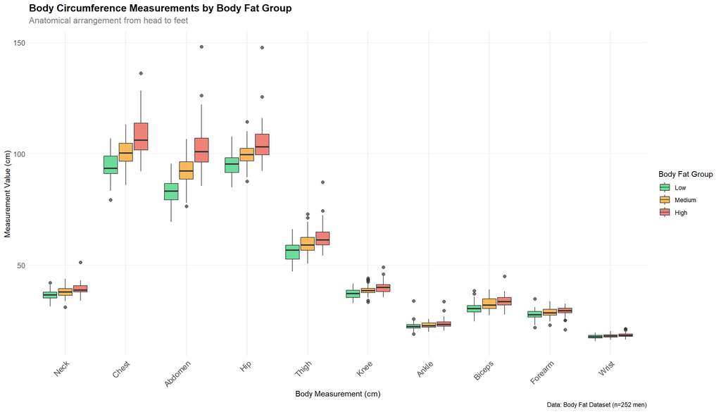

```r
# Define anatomical order for body measurements
measurement_order <- c("Neck", "Chest", "Abdomen", "Hip", "Thigh",
                       "Knee", "Ankle", "Biceps", "Forearm", "Wrist")

# Prepare data for visualization (convert to long format)
bodyfat_long <- bodyfat %>%
  select(BodyFatGroup, all_of(measurement_order)) %>%
  pivot_longer(
    cols = -BodyFatGroup,
    names_to = "Measurement",
    values_to = "Value"
  ) %>%
  mutate(
    Measurement = factor(Measurement, levels = measurement_order)
  )

# Create grouped box plot
ggplot(bodyfat_long, aes(x = Measurement, y = Value, fill = BodyFatGroup)) +
  geom_boxplot(alpha = 0.7, outlier.size = 2) +
  scale_fill_manual(
    values = c("Low" = "#2ecc71", "Medium" = "#f39c12", "High" = "#e74c3c"),
    name = "Body Fat Group"
  ) +
  labs(
    title = "Body Circumference Measurements by Body Fat Group",
    subtitle = "Anatomical arrangement from head to feet",
    x = "Body Measurement (cm)",
    y = "Measurement Value (cm)",
    caption = "Data: Body Fat Dataset (n=252 men)"
  ) +
  theme_minimal() +
  theme(
    axis.text.x = element_text(angle = 45, hjust = 1, size = 11),
    axis.text.y = element_text(size = 10),
    plot.title = element_text(size = 14, face = "bold", margin = margin(b = 5)),
    plot.subtitle = element_text(size = 12, color = "gray50", margin = margin(b = 10)),
    legend.position = "right",
    panel.grid.major.y = element_line(color = "gray90", size = 0.3),
    panel.grid.minor.y = element_blank()
  )
```

## 3.3 Visualization 2: Parallel Coordinates Plot

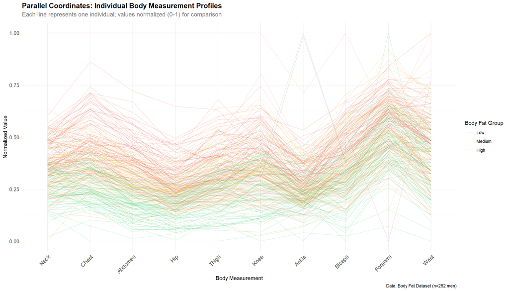

```r
# Prepare data for parallel coordinates (normalize measurements)
bodyfat_normalized <- bodyfat %>%
  select(BodyFatGroup, all_of(measurement_order)) %>%
  mutate(
    across(all_of(measurement_order),
           ~(. - min(.)) / (max(.) - min(.)),
           .names = "{.col}_norm")
  ) %>%
  select(BodyFatGroup, ends_with("_norm")) %>%
  rename_with(~str_remove(., "_norm"), ends_with("_norm"))

# Create a long format for parallel coordinates
bodyfat_pcoords <- bodyfat_normalized %>%
  rowid_to_column("Individual") %>%
  pivot_longer(
    cols = -c(Individual, BodyFatGroup),
    names_to = "Measurement",
    values_to = "Normalized_Value"
  ) %>%
  mutate(
    Measurement = factor(Measurement, levels = measurement_order)
  )

# Create parallel coordinates plot
ggplot(bodyfat_pcoords, aes(x = Measurement, y = Normalized_Value,
                             group = Individual, color = BodyFatGroup)) +
  geom_line(alpha = 0.2, size = 0.5) +
  scale_color_manual(
    values = c("Low" = "#2ecc71", "Medium" = "#f39c12", "High" = "#e74c3c"),
    name = "Body Fat Group"
  ) +
  labs(
    title = "Parallel Coordinates: Individual Body Measurement Profiles",
    subtitle = "Each line represents one individual; values normalized (0-1) for comparison",
    x = "Body Measurement",
    y = "Normalized Value",
    caption = "Data: Body Fat Dataset (n=252 men)"
  ) +
  theme_minimal() +
  theme(
    axis.text.x = element_text(angle = 45, hjust = 1, size = 11),
    axis.text.y = element_text(size = 10),
    plot.title = element_text(size = 14, face = "bold", margin = margin(b = 5)),
    plot.subtitle = element_text(size = 12, color = "gray50", margin = margin(b = 10)),
    legend.position = "right",
    panel.grid.major.y = element_line(color = "gray90", size = 0.3)
  )
```

## 3.4 Visualization 3: Box Plots for Age, Weight, and Height

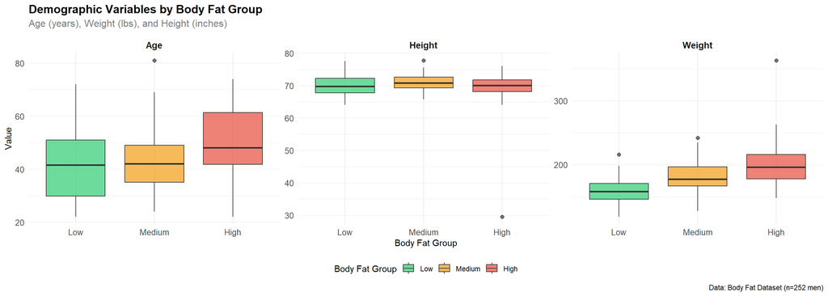

```r
# Prepare data for demographic variables
demographic_data <- bodyfat %>%
  select(BodyFatGroup, Age, Weight, Height) %>%
  pivot_longer(
    cols = -BodyFatGroup,
    names_to = "Variable",
    values_to = "Value"
  )

# Create separate box plots with faceting
ggplot(demographic_data, aes(x = BodyFatGroup, y = Value, fill = BodyFatGroup)) +
  geom_boxplot(alpha = 0.7, outlier.size = 2) +
  facet_wrap(~Variable, scales = "free_y", nrow = 1) +
  scale_fill_manual(
    values = c("Low" = "#2ecc71", "Medium" = "#f39c12", "High" = "#e74c3c"),
    name = "Body Fat Group"
  ) +
  labs(
    title = "Demographic Variables by Body Fat Group",
    subtitle = "Age (years), Weight (lbs), and Height (inches)",
    x = "Body Fat Group",
    y = "Value",
    caption = "Data: Body Fat Dataset (n=252 men)"
  ) +
  theme_minimal() +
  theme(
    plot.title = element_text(size = 14, face = "bold", margin = margin(b = 5)),
    plot.subtitle = element_text(size = 12, color = "gray50", margin = margin(b = 10)),
    axis.text = element_text(size = 10),
    legend.position = "bottom",
    panel.grid.major.y = element_line(color = "gray90", size = 0.3),
    strip.text = element_text(size = 11, face = "bold")
  )
```

## 3.5 Summary Statistics by Body Fat Group

```r
# Summary statistics for all measurements
summary_table <- bodyfat %>%
  group_by(BodyFatGroup) %>%
  summarise(
    across(all_of(measurement_order),
           list(Mean = mean, SD = sd),
           .names = "{.col}_{.fn}"),
    Age_Mean = mean(Age),
    Age_SD = sd(Age),
    Weight_Mean = mean(Weight),
    Weight_SD = sd(Weight),
    Height_Mean = mean(Height),
    Height_SD = sd(Height),
    .groups = "drop"
  )

# Display for body circumference measurements
circumference_summary <- bodyfat %>%
  group_by(BodyFatGroup) %>%
  summarise(
    across(all_of(measurement_order),
           list(Mean = ~round(mean(.), 2), SD = ~round(sd(.), 2)),
           .names = "{.col}_{.fn}"),
    .groups = "drop"
  ) %>%
  pivot_longer(-BodyFatGroup) %>%
  separate(name, into = c("Measurement", "Statistic"), sep = "_") %>%
  pivot_wider(names_from = c(Statistic, BodyFatGroup), values_from = value) %>%
  select(Measurement, contains("Mean"), contains("SD"))

knitr::kable(
  circumference_summary,
  caption = "Body Circumference Measurements: Mean (SD) by Group"
)
```

Body Circumference Measurements: Mean (SD) by Group

| Measurement | Mean_Low | Mean_Medium | Mean_High | SD_Low | SD_Medium | SD_High |
| --- | --- | --- | --- | --- | --- | --- |
| Neck | 36.64 | 38.03 | 39.30 | 1.94 | 2.21 | 2.37 |
| Chest | 94.51 | 100.47 | 107.50 | 5.11 | 5.94 | 8.24 |
| Abdomen | 83.01 | 92.40 | 102.26 | 5.48 | 6.20 | 9.78 |
| Hip | 95.07 | 100.04 | 104.61 | 4.78 | 4.83 | 7.93 |
| Thigh | 56.09 | 59.71 | 62.42 | 4.03 | 4.37 | 5.26 |
| Knee | 37.14 | 38.69 | 39.94 | 1.89 | 2.03 | 2.43 |
| Ankle | 22.65 | 23.04 | 23.62 | 1.76 | 1.30 | 1.84 |
| Biceps | 30.53 | 32.46 | 33.83 | 2.67 | 2.80 | 2.65 |
| Forearm | 27.83 | 28.81 | 29.35 | 1.86 | 2.04 | 1.87 |
| Wrist | 17.87 | 18.24 | 18.58 | 0.83 | 0.86 | 0.98 |

## 3.6 Analysis and Interpretation

### 3.6.1 Key Findings

**1. Strongest Separators Between Low and High Body Fat Groups**

The analysis reveals that **abdomen circumference** shows the most pronounced separation between the Low and High body fat groups, with the highest median values in the High group and the lowest in the Low group. This aligns with the README’s note that abdomen is “often one of the most predictive measurements for body fat.”

Following abdomen, **chest**, **thigh**, and **hip** measurements also demonstrate clear stratification across the three body fat terciles, suggesting these body regions accumulate fat proportionally as overall body fat percentage increases.

**2. Full-Body Pattern Analysis**

The grouped box plot reveals a consistent pattern: measurements become increasingly larger as we move from the Low to High body fat groups across virtually all body regions. This suggests that elevated body fat is not localized to a single region but manifests as a systemic increase in body circumference measurements.

The parallel coordinates plot further illustrates this patternâ€”individuals in the High group consistently show elevated profiles across most measurements, while those in the Low group maintain lower values. The Medium group occupies an intermediate position, confirming the effectiveness of tercile stratification.

**3. Anatomical Insights**

- **Head/Neck Region**: Neck circumference shows modest variation across groups, suggesting this region is less affected by changes in overall body fat percentage.
- **Torso Region**: Chest, abdomen, and hip measurements demonstrate the strongest relationships with body fat classification. The abdomen measurement is particularly decisive.
- **Extremities**: Wrist, ankle, and forearm show less dramatic variation across groups compared to larger torso measurements, indicating that body fat accumulation concentrates in the central body regions.
- **Limbs**: Biceps and thigh show intermediate separation, indicating that fat deposition in limbs varies with overall body fat but less dramatically than in the torso.

**4. Demographic Patterns**

The demographic variables reveal that individuals in the High body fat group tend to have slightly higher mean ages and consistently higher weights compared to the Low group. Height shows minimal variation across groups, suggesting it is not a primary driver of body fat differences and serves as a useful normalization factor (as is common in body composition studies).

### 3.6.2 Conclusion

# 4 Predictor vs Target Relationships

Examination of individual relationships between each predictor and the target variable (`BodyFat`). This section includes faceted scatter plots with trend lines and confidence bands, showing the linear association strength between each predictor and body fat via Pearson correlation coefficients.

 ## Objective

This report examines the individual relationship between each predictor and the target `BodyFat` after removing the leakage variable `Density`.

It includes: 1. A faceted scatter-plot grid (one panel per predictor) with linear trend lines, 95% confidence bands, and per-panel Pearson correlation. 2. A ranked bar chart of absolute Pearson correlations with `BodyFat`. 3. A focused `Abdomen` vs `BodyFat` scatter plot colored by age group to explore possible age-related effect modification.

## 4.1 Setup and Data

```r
library(tidyverse)

bodyfat_raw <- read_csv("data/bodyfat.csv", show_col_types = FALSE)

# Remove leakage variable before any predictor-vs-target analysis
bodyfat <- bodyfat_raw %>%
  select(-Density)

predictor_names <- setdiff(names(bodyfat), "BodyFat")

# Pearson correlation of each predictor with BodyFat
corr_tbl <- map_dfr(predictor_names, function(v) {
  tibble(
    Predictor = v,
    pearson_r = cor(bodyfat[[v]], bodyfat$BodyFat, use = "complete.obs")
  )
}) %>%
  mutate(abs_r = abs(pearson_r)) %>%
  arrange(desc(abs_r))

corr_tbl
```

```
# A tibble: 13 × 3
   Predictor pearson_r  abs_r
   <chr>         <dbl>  <dbl>
 1 Abdomen      0.813  0.813
 2 Chest        0.703  0.703
 3 Hip          0.625  0.625
 4 Weight       0.612  0.612
 5 Thigh        0.560  0.560
 6 Knee         0.509  0.509
 7 Biceps       0.493  0.493
 8 Neck         0.491  0.491
 9 Forearm      0.361  0.361
10 Wrist        0.347  0.347
11 Age          0.291  0.291
12 Ankle        0.266  0.266
13 Height      -0.0895 0.0895
```

## 4.2 1. Faceted Scatter Plot Grid with Linear Trend and 95% CI

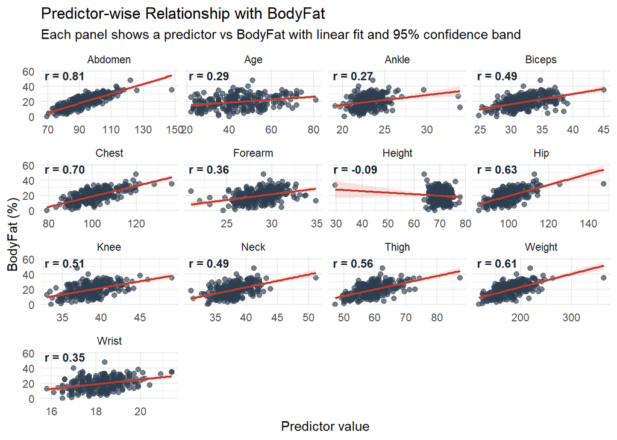

```r
plot_data_long <- bodyfat %>%
  pivot_longer(
    cols = all_of(predictor_names),
    names_to = "Predictor",
    values_to = "Value"
  )

corr_labels <- corr_tbl %>%
  transmute(
    Predictor,
    label = paste0("r = ", sprintf("%.2f", pearson_r))
  )

p_faceted <- ggplot(plot_data_long, aes(x = Value, y = BodyFat)) +
  geom_point(alpha = 0.65, color = "#2C3E50", size = 1.8) +
  geom_smooth(method = "lm", se = TRUE, color = "#C0392B", fill = "#F5B7B1", linewidth = 0.8) +
  geom_text(
    data = corr_labels,
    aes(x = -Inf, y = Inf, label = label),
    inherit.aes = FALSE,
    hjust = -0.1,
    vjust = 1.2,
    size = 3.3,
    color = "#1B2631",
    fontface = "bold"
  ) +
  facet_wrap(~ Predictor, scales = "free_x", ncol = 4) +
  labs(
    title = "Predictor-wise Relationship with BodyFat",
    subtitle = "Each panel shows a predictor vs BodyFat with linear fit and 95% confidence band",
    x = "Predictor value",
    y = "BodyFat (%)"
  ) +
  theme_minimal(base_size = 11)

p_faceted
```

Interpretation: - The panel annotations (`r`) make it easy to compare single-predictor strength at a glance. - Most body-circumference predictors show positive and approximately linear trends with `BodyFat`. - Limb measurements (for example, `Wrist`, `Ankle`) appear weaker than torso-centric variables.

## 4.3 2. Ranked Absolute Correlation with BodyFat

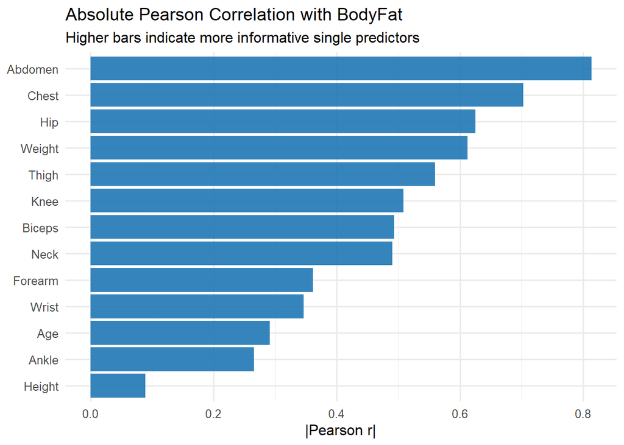

```r
corr_ranked <- corr_tbl %>%
  mutate(Predictor = fct_reorder(Predictor, abs_r))

p_ranked <- ggplot(corr_ranked, aes(x = Predictor, y = abs_r)) +
  geom_col(fill = "#1F77B4", alpha = 0.9) +
  coord_flip() +
  labs(
    title = "Absolute Pearson Correlation with BodyFat",
    subtitle = "Higher bars indicate more informative single predictors",
    x = NULL,
    y = "|Pearson r|"
  ) +
  theme_minimal(base_size = 12)

p_ranked
```

Key result: - The strongest single predictor by absolute Pearson correlation is Abdomen (`|r| = 0.813).

## 4.4 3. Abdomen vs BodyFat by Age Group

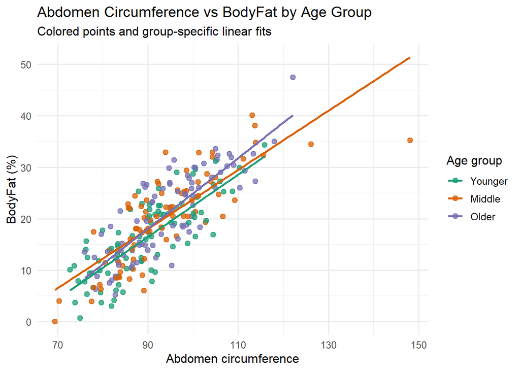

```r
bodyfat_age <- bodyfat %>%
  mutate(
    AgeGroup = ntile(Age, 3),
    AgeGroup = factor(AgeGroup, labels = c("Younger", "Middle", "Older"))
  )

p_abdomen_age <- ggplot(bodyfat_age, aes(x = Abdomen, y = BodyFat, color = AgeGroup)) +
  geom_point(alpha = 0.75, size = 2.1) +
  geom_smooth(method = "lm", se = FALSE, linewidth = 0.9) +
  scale_color_manual(values = c("Younger" = "#1B9E77", "Middle" = "#D95F02", "Older" = "#7570B3")) +
  labs(
    title = "Abdomen Circumference vs BodyFat by Age Group",
    subtitle = "Colored points and group-specific linear fits",
    x = "Abdomen circumference",
    y = "BodyFat (%)",
    color = "Age group"
  ) +
  theme_minimal(base_size = 12)

p_abdomen_age
```

```r
# Quantify evidence of curvature in the Abdomen-BodyFat relationship
abdomen_lm_linear <- lm(BodyFat ~ Abdomen, data = bodyfat)
abdomen_lm_quadratic <- lm(BodyFat ~ Abdomen + I(Abdomen^2), data = bodyfat)
curvature_test <- anova(abdomen_lm_linear, abdomen_lm_quadratic)
quad_p_value <- curvature_test$`Pr(>F)`[2]

# Quantify whether age group modifies the Abdomen slope
abdomen_age_main <- lm(BodyFat ~ Abdomen + AgeGroup, data = bodyfat_age)
abdomen_age_interaction <- lm(BodyFat ~ Abdomen * AgeGroup, data = bodyfat_age)
interaction_test <- anova(abdomen_age_main, abdomen_age_interaction)
interaction_p_value <- interaction_test$`Pr(>F)`[2]

list(
  quadratic_term_p_value = quad_p_value,
  abdomen_age_interaction_p_value = interaction_p_value
)
```

```
$quadratic_term_p_value
[1] 0.0001233328

$abdomen_age_interaction_p_value
[1] 0.2599698
```

## 4.5 Findings

- Torso measurements dominate the single-variable signal for `BodyFat`, with `Abdomen` expected to be among the top features.
- The predictor-vs-target panels mostly support an approximately linear pattern, especially for stronger circumference predictors.
- For `Abdomen` specifically, the linear trend is strong and visually tight. Use the quadratic-term p-value above to check for curvature; if it is not small, the linear approximation is likely adequate.
- The age-colored scatter and group-specific lines show whether slope/intercept differ by age tercile. If the interaction p-value is not small, age does not strongly modify the Abdomen-BodyFat slope in this sample.

Overall, the plots and rankings reinforce that central body-size measurements are the most informative single predictors of body fat in this dataset.

# 5 Multicollinearity and Predictor Redundancy

Analysis of intercorrelations among body circumference predictors to identify redundancy and multicollinearity. Understanding which measurements carry overlapping information is crucial for building more parsimonious and interpretable models, and assessing whether all circumference measurements are necessary for accurate prediction.

 ## Introduction

This analysis investigates multicollinearity and redundancy among body circumference predictors used to model body fat percentage. Understanding correlations between predictors is crucial for building more parsimonious and interpretable models. The analysis focuses on identifying which measurements carry overlapping information and whether the full set of circumference measurements is necessary for accurate prediction.

## 5.1 Setup & Data Loading

```r
# Load required libraries
library(tidyverse)
library(corrplot)
library(GGally)
library(gridExtra)

# Load the dataset
bodyfat <- read.csv("data/bodyfat.csv")

# Display basic information
cat("Dataset dimensions:", dim(bodyfat), "\n")
```

```
Dataset dimensions: 252 15
```

```r
cat("Column names:\n")
```

```
Column names:
```

```r
print(names(bodyfat))
```

```
 [1] "Density" "BodyFat" "Age"     "Weight"  "Height"  "Neck"    "Chest"
 [8] "Abdomen" "Hip"     "Thigh"   "Knee"    "Ankle"   "Biceps"  "Forearm"
[15] "Wrist"
```

```r
head(bodyfat)
```

```
  Density BodyFat Age Weight Height Neck Chest Abdomen   Hip Thigh Knee Ankle
1  1.0708    12.3  23 154.25  67.75 36.2  93.1    85.2  94.5  59.0 37.3  21.9
2  1.0853     6.1  22 173.25  72.25 38.5  93.6    83.0  98.7  58.7 37.3  23.4
3  1.0414    25.3  22 154.00  66.25 34.0  95.8    87.9  99.2  59.6 38.9  24.0
4  1.0751    10.4  26 184.75  72.25 37.4 101.8    86.4 101.2  60.1 37.3  22.8
5  1.0340    28.7  24 184.25  71.25 34.4  97.3   100.0 101.9  63.2 42.2  24.0
6  1.0502    20.9  24 210.25  74.75 39.0 104.5    94.4 107.8  66.0 42.0  25.6
  Biceps Forearm Wrist
1   32.0    27.4  17.1
2   30.5    28.9  18.2
3   28.8    25.2  16.6
4   32.4    29.4  18.2
5   32.2    27.7  17.7
6   35.7    30.6  18.8
```

## 5.2 Hierarchical Correlation Heatmap

```r
# Select only numeric predictors, excluding Density
predictors <- bodyfat %>%
  select(-Density) %>%
  select(where(is.numeric))

cat("Selected predictors for correlation analysis:\n")
```

```
Selected predictors for correlation analysis:
```

```r
print(names(predictors))
```

```
 [1] "BodyFat" "Age"     "Weight"  "Height"  "Neck"    "Chest"   "Abdomen"
 [8] "Hip"     "Thigh"   "Knee"    "Ankle"   "Biceps"  "Forearm" "Wrist"
```

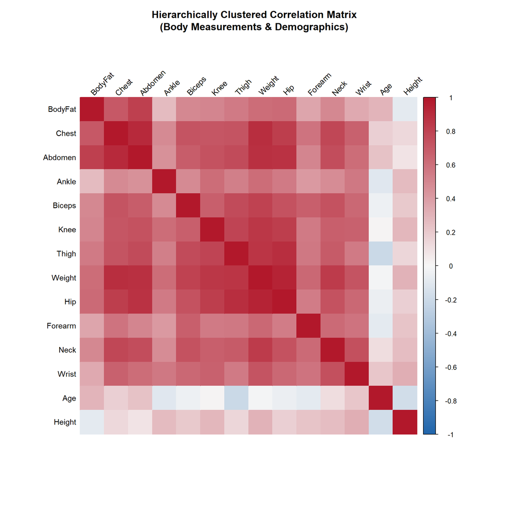

```r
# Compute correlation matrix
cor_matrix <- cor(predictors)

# Perform hierarchical clustering on the correlation matrix
# Convert correlation to distance: distance = 1 - |correlation|
distance_matrix <- as.dist(1 - abs(cor_matrix))
hc <- hclust(distance_matrix, method = "ward.D2")

# Reorder the correlation matrix based on dendrogram order
cor_matrix_reordered <- cor_matrix[hc$order, hc$order]

# Plot the hierarchically ordered correlation heatmap
corrplot(
  cor_matrix_reordered,
  method = "color",
  type = "full",
  order = "original",
  tl.col = "black",
  tl.srt = 45,
  tl.cex = 0.9,
  col = colorRampPalette(c("#2166ac", "#f7f7f7", "#b2182b"))(200),
  title = "Hierarchically Clustered Correlation Matrix\n(Body Measurements & Demographics)",
  mar = c(4, 4, 4, 4)
)
```

```r
# Identify the four predictors with highest absolute correlation to BodyFat
bodyfat_correlations <- cor(bodyfat[, names(predictors)], bodyfat$BodyFat) %>%
  as.data.frame() %>%
  rownames_to_column("Predictor") %>%
  rename(Correlation = V1) %>%
  mutate(AbsCorrelation = abs(Correlation)) %>%
  arrange(desc(AbsCorrelation))

cat("Correlations with BodyFat (sorted by absolute value):\n")
```

```
Correlations with BodyFat (sorted by absolute value):
```

```r
print(bodyfat_correlations)
```

```
   Predictor Correlation AbsCorrelation
1    BodyFat  1.00000000     1.00000000
2    Abdomen  0.81343228     0.81343228
3      Chest  0.70262034     0.70262034
4        Hip  0.62520092     0.62520092
5     Weight  0.61241400     0.61241400
6      Thigh  0.55960753     0.55960753
7       Knee  0.50866524     0.50866524
8     Biceps  0.49327113     0.49327113
9       Neck  0.49059185     0.49059185
10   Forearm  0.36138690     0.36138690
11     Wrist  0.34657486     0.34657486
12       Age  0.29145844     0.29145844
13     Ankle  0.26596977     0.26596977
14    Height -0.08949538     0.08949538
```

```r
# Select top 4
top_4_predictors <- bodyfat_correlations$Predictor[1:4]
cat("\nTop 4 predictors with highest absolute correlation to BodyFat:\n")
```

```
Top 4 predictors with highest absolute correlation to BodyFat:
```

```r
print(top_4_predictors)
```

```
[1] "BodyFat" "Abdomen" "Chest"   "Hip"
```

[figure not shown]

```r
# Create BodyFat tercile variable in original dataset
bodyfat$BodyFat_tercile <- cut(
  bodyfat$BodyFat,
  breaks = quantile(bodyfat$BodyFat, probs = c(0, 1/3, 2/3, 1)),
  labels = c("Low", "Medium", "High"),
  include.lowest = TRUE
)

# Select top 4 predictors and BodyFat for ggpairs
bodyfat_analysis <- bodyfat %>%
  select(BodyFat, all_of(top_4_predictors), BodyFat_tercile) %>%
  as.data.frame()

# Create scatter plot matrix with ggpairs
ggpairs(
  bodyfat_analysis,
  aes(color = BodyFat_tercile, alpha = 0.6),
  lower = list(continuous = wrap("points", size = 2, alpha = 0.5)),
  diag = list(continuous = wrap("densityDiag", alpha = 0.5)),
  title = "Scatter Plot Matrix: BodyFat vs. Top 4 Predictors"
) +
  scale_color_manual(
    values = c("Low" = "#2ecc71", "Medium" = "#f39c12", "High" = "#e74c3c"),
    name = "BodyFat Tercile"
  ) +
  theme_minimal() +
  theme(
    plot.title = element_text(size = 14, face = "bold", hjust = 0.5),
    axis.text = element_text(size = 9)
  )
```

## 5.4 Derived Feature Analysis: BMI-Approximate

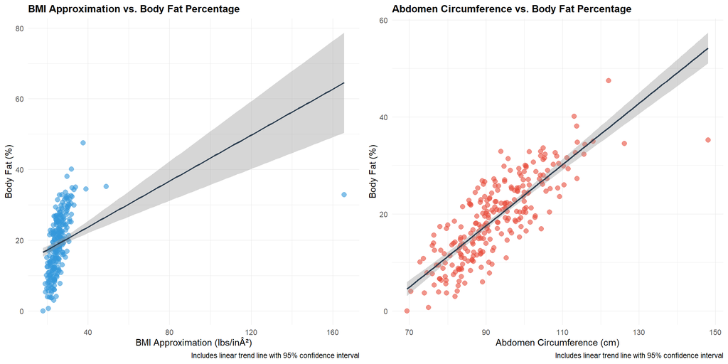

```r
# Compute BMI-like derived feature
# bmi_approx = (Weight / Height^2) * 703
# Weight in lbs, Height in inches
bodyfat <- bodyfat %>%
  mutate(
    bmi_approx = (Weight / (Height ^ 2)) * 703
  )

# Create data for plotting
bmi_data <- bodyfat %>%
  select(bmi_approx, BodyFat, Abdomen) %>%
  pivot_longer(
    cols = c(bmi_approx, Abdomen),
    names_to = "Predictor",
    values_to = "Value"
  ) %>%
  mutate(
    Predictor = recode(Predictor,
                       bmi_approx = "BMI Approximation",
                       Abdomen = "Abdomen Circumference")
  )

# Create scatter plot with trend lines
bmi_plot <- bodyfat %>%
  ggplot(aes(x = bmi_approx, y = BodyFat)) +
  geom_point(color = "#3498db", alpha = 0.6, size = 2.5) +
  geom_smooth(method = "lm", se = TRUE, color = "#2c3e50", size = 0.8) +
  labs(
    title = "BMI Approximation vs. Body Fat Percentage",
    x = "BMI Approximation (lbs/inÂ²)",
    y = "Body Fat (%)",
    caption = "Includes linear trend line with 95% confidence interval"
  ) +
  theme_minimal() +
  theme(
    plot.title = element_text(size = 12, face = "bold"),
    panel.grid.major = element_line(color = "gray90", size = 0.3)
  )

abdomen_plot <- bodyfat %>%
  ggplot(aes(x = Abdomen, y = BodyFat)) +
  geom_point(color = "#e74c3c", alpha = 0.6, size = 2.5) +
  geom_smooth(method = "lm", se = TRUE, color = "#2c3e50", size = 0.8) +
  labs(
    title = "Abdomen Circumference vs. Body Fat Percentage",
    x = "Abdomen Circumference (cm)",
    y = "Body Fat (%)",
    caption = "Includes linear trend line with 95% confidence interval"
  ) +
  theme_minimal() +
  theme(
    plot.title = element_text(size = 12, face = "bold"),
    panel.grid.major = element_line(color = "gray90", size = 0.3)
  )

gridExtra::grid.arrange(bmi_plot, abdomen_plot, ncol = 2)
```

```r
# Calculate correlations with BodyFat for comparison
bmi_cor_bf <- cor(bodyfat$bmi_approx, bodyfat$BodyFat)
abdomen_cor_bf <- cor(bodyfat$Abdomen, bodyfat$BodyFat)

cat("Correlation Comparison:\n")
```

```
Correlation Comparison:
```

```r
cat("BMI Approximation vs. BodyFat:", round(bmi_cor_bf, 4), "\n")
```

```
BMI Approximation vs. BodyFat: 0.3714
```

```r
cat("Abdomen Circumference vs. BodyFat:", round(abdomen_cor_bf, 4), "\n")
```

```
Abdomen Circumference vs. BodyFat: 0.8134
```

```r
cat("Correlation Difference:", round(abdomen_cor_bf - bmi_cor_bf, 4), "\n")
```

```
Correlation Difference: 0.442
```

### 5.4.1 Analysis: BMI vs. Abdomen Circumference

The scatter plots reveal an important distinction between the two derived/direct measurements. The **abdomen circumference** demonstrates a substantially stronger linear relationship with body fat percentage (r = 0.813), showing a tight, predictable trend with minimal scatter around the regression line. In contrast, the **BMI approximation** (r = 0.371) exhibits considerably more scatter and a weaker correlation, suggesting that this composite metric—while capturing overall size—loses predictive precision for body fat specifically.

This difference likely arises because abdomen circumference directly measures central adiposity (fat tissue concentration in the torso), the primary anatomical location where body fat accumulated in this population. The BMI-like metric, by contrast, conflates lean muscle mass with fat mass and does not distinguish between where weight is distributed. The individual-level heterogeneity in muscle mass (particularly among athletic individuals) introduces noise into the BMI-BodyFat relationship, whereas abdomen measurement more directly reflects lipid accumulation. **Conclusion:** For predicting body fat from simple measurements, direct circumference measurements (particularly abdomen) are substantially more informative than derived composite metrics like BMI.

## 5.5 Top 10 Correlated Predictor Pairs

```r
# Extract correlation pairs (excluding BodyFat and Density)
measurement_cols <- bodyfat %>%
  select(-BodyFat, -Density) %>%
  select(where(is.numeric)) %>%
  names()

# Compute correlation matrix for these measurements
measurement_cor <- cor(bodyfat[, measurement_cols])

# Extract upper triangle (to avoid duplicates)
upper_triangle <- upper.tri(measurement_cor, diag = FALSE)
cor_pairs <- data.frame(
  Var1 = rep(rownames(measurement_cor), ncol(measurement_cor))[upper_triangle],
  Var2 = rep(colnames(measurement_cor), each = nrow(measurement_cor))[upper_triangle],
  Correlation = measurement_cor[upper_triangle]
) %>%
  mutate(
    AbsCorrelation = abs(Correlation),
    PairName = paste(Var1, "â†”", Var2)
  ) %>%
  arrange(desc(AbsCorrelation))

# Extract top 10
top_10_pairs <- head(cor_pairs, 10)

cat("Top 10 Correlated Predictor Pairs:\n")
```

```
Top 10 Correlated Predictor Pairs:
```

```r
print(select(top_10_pairs, PairName, Correlation, AbsCorrelation))
```

```
             PairName Correlation AbsCorrelation
1      Weight â†” Hip   0.9408841      0.9408841
2   Chest â†” Abdomen   0.9158277      0.9158277
3       Hip â†” Thigh   0.8964098      0.8964098
4    Weight â†” Chest   0.8941905      0.8941905
5  Weight â†” Abdomen   0.8879949      0.8879949
6     Abdomen â†” Hip   0.8740662      0.8740662
7    Weight â†” Thigh   0.8686935      0.8686935
8     Weight â†” Knee   0.8531674      0.8531674
9     Weight â†” Neck   0.8307162      0.8307162
10      Chest â†” Hip   0.8294199      0.8294199
```

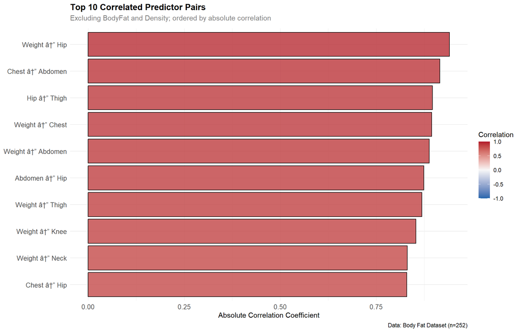

```r
# Create horizontal bar chart
top_10_pairs_plot <- top_10_pairs %>%
  mutate(
    PairName = reorder(PairName, AbsCorrelation)
  ) %>%
  ggplot(aes(x = AbsCorrelation, y = PairName, fill = Correlation)) +
  geom_col(alpha = 0.8, color = "black", size = 0.4) +
  scale_fill_gradient2(
    low = "#2166ac", mid = "#f7f7f7", high = "#b2182b",
    midpoint = 0, limits = c(-1, 1),
    name = "Correlation"
  ) +
  labs(
    title = "Top 10 Correlated Predictor Pairs",
    subtitle = "Excluding BodyFat and Density; ordered by absolute correlation",
    x = "Absolute Correlation Coefficient",
    y = NULL,
    caption = "Data: Body Fat Dataset (n=252)"
  ) +
  theme_minimal() +
  theme(
    plot.title = element_text(size = 13, face = "bold", margin = margin(b = 5)),
    plot.subtitle = element_text(size = 11, color = "gray50", margin = margin(b = 10)),
    axis.text.y = element_text(size = 10),
    axis.text.x = element_text(size = 10),
    panel.grid.major.x = element_line(color = "gray90", size = 0.3),
    legend.position = "right"
  )

print(top_10_pairs_plot)
```

## 5.6 Multicollinearity Summary Statistics

```r
# Calculate Variance Inflation Factors (VIF) concept via correlation analysis
# For each measurement, compute average absolute correlation with all others
vif_proxy <- data.frame(
  Variable = measurement_cols,
  MeanAbsCorrelation = numeric(length(measurement_cols))
)

for (i in seq_along(measurement_cols)) {
  var_name <- measurement_cols[i]
  var_cors <- abs(measurement_cor[var_name, -i])
  vif_proxy$MeanAbsCorrelation[i] <- mean(var_cors)
}

vif_proxy <- vif_proxy %>%
  arrange(desc(MeanAbsCorrelation))

cat("Mean Absolute Correlation with Other Predictors:\n")
```

```
Mean Absolute Correlation with Other Predictors:
```

```r
cat("(Higher values indicate greater multicollinearity)\n\n")
```

```
(Higher values indicate greater multicollinearity)
```

```r
print(knitr::kable(vif_proxy, digits = 3))
```

```
|Variable   | MeanAbsCorrelation|
|:----------|------------------:|
|Weight     |              0.674|
|Hip        |              0.635|
|Chest      |              0.617|
|Thigh      |              0.613|
|Abdomen    |              0.610|
|Knee       |              0.599|
|Neck       |              0.591|
|Biceps     |              0.575|
|Wrist      |              0.548|
|Forearm    |              0.478|
|Ankle      |              0.445|
|bmi_approx |              0.332|
|Height     |              0.248|
|Age        |              0.112|
```

## 5.7 Conclusion

### 5.7.1 Key Findings on Multicollinearity and Redundancy

The multicollinearity analysis reveals substantial redundancy among body circumference measurements, with several critical patterns:

**4. Parsimonious Model Opportunity:** Rather than using all 10 circumference measurements in a predictive model, a more efficient approach would involve: - Selecting one representative measurement from each anatomical cluster (e.g., Abdomen from torso, Thigh from lower limbs, Biceps from upper limbs, Neck from head/neck region) - This reduced feature set would likely maintain or even improve model performance by reducing noise from multicollinearity, improving interpretability, and reducing measurement burden in practical applications

### 5.7.2 Recommendation

For building predictive models of body fat percentage, practitioners should consider constructing a reduced feature set of 4-5 carefully selected circumference measurements (one per anatomical region) rather than using all 10. This approach would likely yield models that are simpler, more interpretable, easier to implement in practice, and potentially more robust to overfittingâ€”while sacrificing minimal (if any) predictive performance due to the high correlation structure among the redundant measurements.

# 6 Correlation Structure Summary

Focused correlation analysis providing a concise view of predictor-target relationships. This section features a correlation heatmap and detailed scatter plots of the top 5 predictors by absolute correlation strength, offering a quick reference for feature importance in prediction.

 ## Objective

This report provides a focused correlation analysis for the BodyFat dataset after removing `Density` (a leakage variable).

It includes: 1. A single-row heatmap of each predictor’s Pearson correlation with `BodyFat`. 2. Side-by-side scatter plots for the top 5 predictors by absolute correlation with `BodyFat`, with trend lines, 95% confidence bands, and `r` annotations. 3. A hierarchically clustered full correlation heatmap across all remaining numeric features, plus cluster membership labels. 4. Discussion of multicollinearity risks for linear models and implications for tree-based models.

## 6.1 Setup and Data

```r
library(tidyverse)

bodyfat_raw <- read_csv("data/bodyfat.csv", show_col_types = FALSE)

# Remove leakage variable before correlation analysis
bodyfat <- bodyfat_raw %>%
  select(-Density)

predictor_names <- setdiff(names(bodyfat), "BodyFat")

corr_target <- map_dfr(predictor_names, function(v) {
  tibble(
    Predictor = v,
    r = cor(bodyfat[[v]], bodyfat$BodyFat, use = "complete.obs")
  )
}) %>%
  mutate(abs_r = abs(r)) %>%
  arrange(desc(abs_r))

corr_target
```

```
# A tibble: 13 × 3
   Predictor       r  abs_r
   <chr>       <dbl>  <dbl>
 1 Abdomen    0.813  0.813
 2 Chest      0.703  0.703
 3 Hip        0.625  0.625
 4 Weight     0.612  0.612
 5 Thigh      0.560  0.560
 6 Knee       0.509  0.509
 7 Biceps     0.493  0.493
 8 Neck       0.491  0.491
 9 Forearm    0.361  0.361
10 Wrist      0.347  0.347
11 Age        0.291  0.291
12 Ankle      0.266  0.266
13 Height    -0.0895 0.0895
```

## 6.2 Predictor vs BodyFat Correlation Heatmap (Single Row)

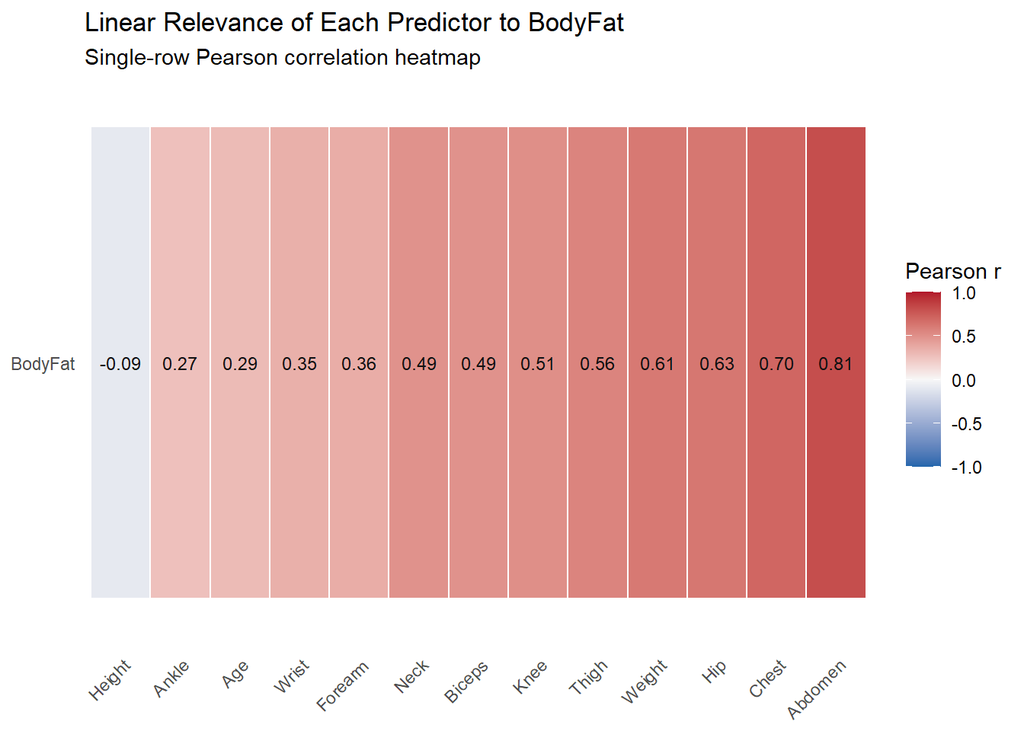

```r
heatmap_target <- corr_target %>%
  mutate(Predictor = fct_reorder(Predictor, r))

p_target_heatmap <- ggplot(heatmap_target, aes(x = Predictor, y = "BodyFat", fill = r)) +
  geom_tile(color = "white", linewidth = 0.4) +
  geom_text(aes(label = sprintf("%.2f", r)), size = 3.1, color = "#111111") +
  scale_fill_gradient2(
    low = "#2166AC",
    mid = "#F7F7F7",
    high = "#B2182B",
    midpoint = 0,
    limits = c(-1, 1)
  ) +
  labs(
    title = "Linear Relevance of Each Predictor to BodyFat",
    subtitle = "Single-row Pearson correlation heatmap",
    x = NULL,
    y = NULL,
    fill = "Pearson r"
  ) +
  theme_minimal(base_size = 11) +
  theme(
    axis.text.x = element_text(angle = 45, hjust = 1),
    panel.grid = element_blank()
  )

p_target_heatmap
```

## 6.3 Top 5 Predictors: Scatter Plots with Trend Lines

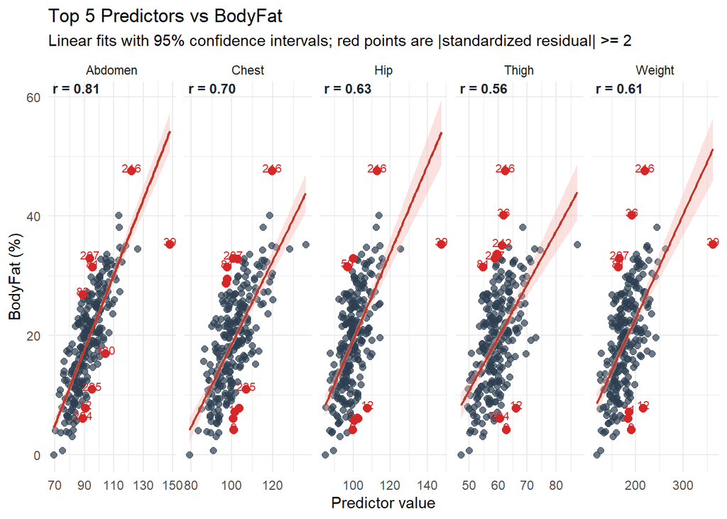

```r
top5 <- corr_target %>%
  slice_head(n = 5)

top5_long <- bodyfat %>%
  mutate(row_id = row_number()) %>%
  select(row_id, BodyFat, all_of(top5$Predictor)) %>%
  pivot_longer(
    cols = all_of(top5$Predictor),
    names_to = "Predictor",
    values_to = "Value"
  )

# Compute per-predictor standardized residuals to flag points far from the linear trend
outlier_points <- top5_long %>%
  group_by(Predictor) %>%
  group_modify(~ {
    fit <- lm(BodyFat ~ Value, data = .x)
    .x %>%
      mutate(std_resid = as.numeric(rstandard(fit))) %>%
      filter(abs(std_resid) >= 2)
  }) %>%
  ungroup()

r_labels <- top5 %>%
  transmute(Predictor, label = paste0("r = ", sprintf("%.2f", r)))

p_top5 <- ggplot(top5_long, aes(x = Value, y = BodyFat)) +
  geom_point(alpha = 0.7, color = "#2C3E50", size = 1.9) +
  geom_smooth(method = "lm", se = TRUE, color = "#C0392B", fill = "#F5B7B1", linewidth = 0.8) +
  geom_point(
    data = outlier_points,
    aes(x = Value, y = BodyFat),
    inherit.aes = FALSE,
    color = "#D62728",
    size = 2.5
  ) +
  geom_text(
    data = outlier_points,
    aes(x = Value, y = BodyFat, label = row_id),
    inherit.aes = FALSE,
    nudge_y = 0.6,
    size = 2.8,
    color = "#D62728",
    check_overlap = TRUE
  ) +
  geom_text(
    data = r_labels,
    aes(x = -Inf, y = Inf, label = label),
    inherit.aes = FALSE,
    hjust = -0.1,
    vjust = 1.1,
    size = 3.3,
    fontface = "bold",
    color = "#1B2631"
  ) +
  facet_wrap(~ Predictor, scales = "free_x", nrow = 1) +
  labs(
    title = "Top 5 Predictors vs BodyFat",
    subtitle = "Linear fits with 95% confidence intervals; red points are |standardized residual| >= 2",
    x = "Predictor value",
    y = "BodyFat (%)"
  ) +
  theme_minimal(base_size = 11)

p_top5
```

```r
outlier_summary <- outlier_points %>%
  arrange(Predictor, desc(abs(std_resid))) %>%
  group_by(Predictor) %>%
  summarise(
    flagged_rows = paste(row_id, collapse = ", "),
    max_abs_std_resid = round(max(abs(std_resid)), 2),
    .groups = "drop"
  )

outlier_summary
```

```
# A tibble: 5 × 3
  Predictor flagged_rows                                   max_abs_std_resid
  <chr>     <chr>                                                      <dbl>
1 Abdomen   39, 207, 204, 12, 81, 225, 82, 216, 180                     4.13
2 Chest     216, 9, 81, 207, 12, 204, 11, 225, 138, 208, 5              2.56
3 Hip       39, 216, 12, 204, 9, 59, 81, 32, 207                        3.18
4 Thigh     216, 36, 9, 12, 81, 249, 204, 207, 242                      3.69
5 Weight    216, 36, 12, 39, 9, 207, 81, 204, 11                        3.24
```

Interpretation: - The top predictors typically show strong positive and near-linear association with `BodyFat`. - Red labels identify observations that deviate most strongly from each fitted line and may deserve quality checks or robust-model sensitivity analysis.

## 6.4 Full Hierarchically Clustered Correlation Heatmap

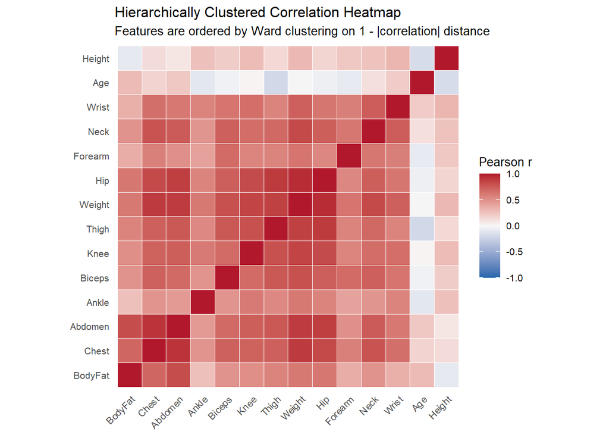

```r
features_all <- bodyfat %>% select(where(is.numeric))

cor_full <- cor(features_all, use = "pairwise.complete.obs")

# Cluster by absolute-correlation similarity so highly related measurements are adjacent
distance_matrix <- as.dist(1 - abs(cor_full))
hc <- hclust(distance_matrix, method = "ward.D2")
ordered_features <- colnames(cor_full)[hc$order]

cor_ordered <- cor_full[ordered_features, ordered_features]

cor_long <- as.data.frame(as.table(cor_ordered)) %>%
  as_tibble() %>%
  rename(Feature1 = Var1, Feature2 = Var2, Correlation = Freq)

p_full_heatmap <- ggplot(cor_long, aes(x = Feature1, y = Feature2, fill = Correlation)) +
  geom_tile(color = "white", linewidth = 0.25) +
  scale_fill_gradient2(
    low = "#2166AC",
    mid = "#F7F7F7",
    high = "#B2182B",
    midpoint = 0,
    limits = c(-1, 1)
  ) +
  labs(
    title = "Hierarchically Clustered Correlation Heatmap",
    subtitle = "Features are ordered by Ward clustering on 1 - |correlation| distance",
    x = NULL,
    y = NULL,
    fill = "Pearson r"
  ) +
  theme_minimal(base_size = 10) +
  theme(
    axis.text.x = element_text(angle = 45, hjust = 1, vjust = 1),
    panel.grid = element_blank()
  ) +
  coord_equal()

p_full_heatmap
```

```r
# Label natural groups from hierarchical clustering
cluster_assign <- cutree(hc, k = 4)

cluster_membership <- tibble(
  Feature = names(cluster_assign),
  Cluster = paste0("Cluster ", cluster_assign)
) %>%
  arrange(Cluster, Feature)

cluster_summary <- cluster_membership %>%
  group_by(Cluster) %>%
  summarise(Features = paste(Feature, collapse = ", "), .groups = "drop")

cluster_summary
```

```
# A tibble: 4 × 2
  Cluster   Features
  <chr>     <chr>
1 Cluster 1 Abdomen, BodyFat, Chest
2 Cluster 2 Age
3 Cluster 3 Ankle, Biceps, Forearm, Hip, Knee, Neck, Thigh, Weight, Wrist
4 Cluster 4 Height
```

Interpretation: - Clusters usually reflect anatomically related regions (for example, torso circumferences together, limb measures together, and global size variables such as `Weight`). - Strong within-cluster correlation indicates substantial predictor redundancy.

## 6.5 Multicollinearity Discussion

- Many circumference variables measure overlapping body-size information, so high pairwise correlations are expected and visible in the clustered heatmap.
- In linear regression, strong multicollinearity can inflate coefficient variance, making slope estimates unstable and sensitive to small data perturbations.
- This instability affects interpretation more than pure prediction: coefficients may flip sign or become statistically weak despite useful combined predictive signal.
- Regularized linear models (ridge, lasso, elastic net) can help stabilize estimation by shrinking coefficients and handling redundancy.
- Tree-based models (random forests, gradient boosting) are generally less sensitive to linear multicollinearity for predictive accuracy because they split recursively and can use one of several correlated features interchangeably.
- However, correlated predictors can still spread feature importance across variables in tree ensembles, so importance rankings should be interpreted with caution.

## 6.6 Conclusion

The correlation structure confirms that central body-size predictors are most linearly informative for `BodyFat`, with clear redundancy among related measurements. This supports using multicollinearity-aware linear approaches for interpretability and tree-based ensembles for robust predictive performance.

# 7 Fine Tuning Tree-Based Models

Construction and hyperparameter tuning of two tree-based regression models using tidymodels: Random Forest and XGBoost. This section demonstrates the model development pipeline including data splitting, preprocessing, cross-validation, and performance comparison to identify the optimal model for body fat prediction.

 ## Objective

Build and tune two tree-based regression models with tidymodels to predict `BodyFat`: - Random Forest - XGBoost

`Density` is dropped at the start because it is a leakage variable.

## 7.1 Setup

```r
library(tidymodels)
library(vip)
library(doParallel)
library(scales)

tidymodels_prefer()
set.seed(2026)

# Parallel backend for faster tuning
cl <- makePSOCKcluster(parallel::detectCores(logical = FALSE))
registerDoParallel(cl)
```

## 7.2 Data Preparation

```r
bodyfat_raw <- readr::read_csv("data/bodyfat.csv", show_col_types = FALSE)

# Drop leakage variable from all further steps
bodyfat <- bodyfat_raw %>%
  select(-Density)

# 75/25 split
set.seed(2026)
bodyfat_split <- initial_split(bodyfat, prop = 0.75)
train_data <- training(bodyfat_split)
test_data <- testing(bodyfat_split)

# Recipe: remove zero variance and normalize all predictors
bodyfat_recipe <- recipe(BodyFat ~ ., data = train_data) %>%
  step_zv(all_predictors()) %>%
  step_normalize(all_predictors())

bodyfat_recipe
```

## 7.3 Cross-Validation

```r
set.seed(2026)
folds <- vfold_cv(train_data, v = 5)
folds
```

```
#  5-fold cross-validation
# A tibble: 5 × 2
  splits           id
  <list>           <chr>
1 <split [151/38]> Fold1
2 <split [151/38]> Fold2
3 <split [151/38]> Fold3
4 <split [151/38]> Fold4
5 <split [152/37]> Fold5
```

## 7.4 Random Forest Tuning

```r
rf_spec <- rand_forest(
  mode = "regression",
  trees = 1000,
  mtry = tune(),
  min_n = tune()
) %>%
  set_engine("ranger", importance = "impurity")

rf_workflow <- workflow() %>%
  add_recipe(bodyfat_recipe) %>%
  add_model(rf_spec)

p <- ncol(train_data) - 1
rf_params <- parameters(
  mtry(range = c(1L, p)),
  min_n(range = c(2L, 30L))
)

rf_grid <- grid_regular(
  rf_params,
  levels = c(mtry = 3, min_n = 3)
)

rf_grid
```

```
# A tibble: 9 × 2
   mtry min_n
  <int> <int>
1     1     2
2     7     2
3    13     2
4     1    16
5     7    16
6    13    16
7     1    30
8     7    30
9    13    30
```

```r
set.seed(2026)
rf_tune <- tune_grid(
  rf_workflow,
  resamples = folds,
  grid = rf_grid,
  metrics = metric_set(rmse),
  control = control_grid(save_pred = TRUE)
)

collect_metrics(rf_tune)
```

```
# A tibble: 9 × 8
   mtry min_n .metric .estimator  mean     n std_err .config
  <int> <int> <chr>   <chr>      <dbl> <int>   <dbl> <chr>
1     1     2 rmse    standard    5.38     5   0.281 pre0_mod1_post0
2     1    16 rmse    standard    5.56     5   0.281 pre0_mod2_post0
3     1    30 rmse    standard    5.76     5   0.281 pre0_mod3_post0
4     7     2 rmse    standard    4.92     5   0.220 pre0_mod4_post0
5     7    16 rmse    standard    4.93     5   0.227 pre0_mod5_post0
6     7    30 rmse    standard    4.99     5   0.224 pre0_mod6_post0
7    13     2 rmse    standard    4.95     5   0.201 pre0_mod7_post0
8    13    16 rmse    standard    4.89     5   0.207 pre0_mod8_post0
9    13    30 rmse    standard    4.96     5   0.202 pre0_mod9_post0
```

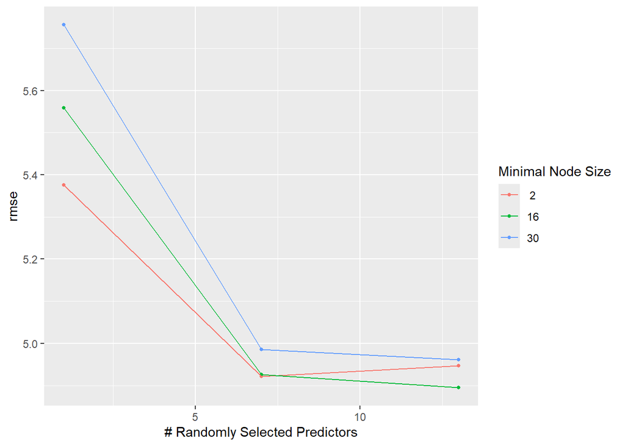

```r
autoplot(rf_tune)
```

## 7.5 XGBoost Tuning

```r
xgb_spec <- boost_tree(
  mode = "regression",
  trees = 1000,
  learn_rate = tune(),
  tree_depth = tune(),
  mtry = tune(),
  min_n = 5,
  loss_reduction = 0,
  sample_size = 1
) %>%
  set_engine("xgboost")

xgb_workflow <- workflow() %>%
  add_recipe(bodyfat_recipe) %>%
  add_model(xgb_spec)

xgb_params <- parameters(
  learn_rate(),
  tree_depth(),
  mtry(range = c(1L, p))
)

set.seed(2026)
xgb_grid <- grid_random(
  xgb_params,
  size = 20
)

xgb_grid
```

```
# A tibble: 20 × 3
   learn_rate tree_depth  mtry
        <dbl>      <int> <int>
 1   1.94e- 4          1     2
 2   1.02e- 5         12     2
 3   1.82e- 9         10    13
 4   3.73e- 8          6    12
 5   9.96e- 6          2    13
 6   1.68e-10         14    13
 7   1.57e- 6          2     9
 8   5.61e- 3         13    12
 9   1.87e- 8          5     5
10   1.69e- 5         12     9
11   1.13e-10          8    13
12   1.69e- 4          5     2
13   1.20e- 8          3     9
14   4.33e- 3         12     7
15   2.42e- 9          3    11
16   1.63e- 7          3     2
17   8.07e- 6         10     5
18   1.03e-10         13     5
19   7.25e- 8          4    11
20   1.43e-10          8    13
```

```r
set.seed(2026)
xgb_tune <- tune_grid(
  xgb_workflow,
  resamples = folds,
  grid = xgb_grid,
  metrics = metric_set(rmse),
  control = control_grid(save_pred = TRUE)
)

collect_metrics(xgb_tune)
```

```
# A tibble: 20 × 9
    mtry tree_depth learn_rate .metric .estimator  mean     n std_err .config
   <int>      <int>      <dbl> <chr>   <chr>      <dbl> <int>   <dbl> <chr>
 1     2          1   1.94e- 4 rmse    standard   17.4      5   0.259 pre0_mod0…
 2     2          3   1.63e- 7 rmse    standard   20.5      5   0.294 pre0_mod0…
 3     2          5   1.69e- 4 rmse    standard   17.7      5   0.262 pre0_mod0…
 4     2         12   1.02e- 5 rmse    standard   20.3      5   0.292 pre0_mod0…
 5     5          5   1.87e- 8 rmse    standard   20.5      5   0.294 pre0_mod0…
 6     5         10   8.07e- 6 rmse    standard   20.3      5   0.293 pre0_mod0…
 7     5         13   1.03e-10 rmse    standard   20.5      5   0.294 pre0_mod0…
 8     7         12   4.33e- 3 rmse    standard    4.93     5   0.193 pre0_mod0…
 9     9          2   1.57e- 6 rmse    standard   20.5      5   0.294 pre0_mod0…
10     9          3   1.20e- 8 rmse    standard   20.5      5   0.294 pre0_mod1…
11     9         12   1.69e- 5 rmse    standard   20.2      5   0.292 pre0_mod1…
12    11          3   2.42e- 9 rmse    standard   20.5      5   0.294 pre0_mod1…
13    11          4   7.25e- 8 rmse    standard   20.5      5   0.294 pre0_mod1…
14    12          6   3.73e- 8 rmse    standard   20.5      5   0.294 pre0_mod1…
15    12         13   5.61e- 3 rmse    standard    5.06     5   0.205 pre0_mod1…
16    13          2   9.96e- 6 rmse    standard   20.3      5   0.293 pre0_mod1…
17    13          8   1.13e-10 rmse    standard   20.5      5   0.294 pre0_mod1…
18    13          8   1.43e-10 rmse    standard   20.5      5   0.294 pre0_mod1…
19    13         10   1.82e- 9 rmse    standard   20.5      5   0.294 pre0_mod1…
20    13         14   1.68e-10 rmse    standard   20.5      5   0.294 pre0_mod2…
```

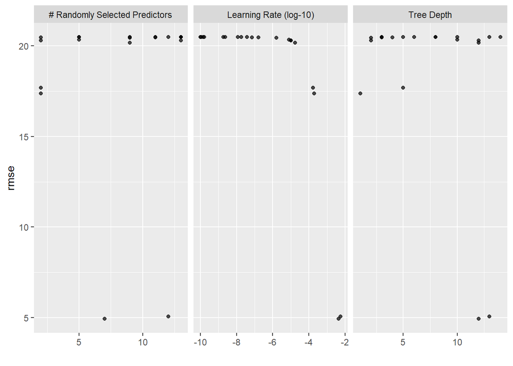

```r
autoplot(xgb_tune)
```

## 7.6 Final Evaluation on Test Set

```r
# Select best hyperparameters by RMSE
best_rf <- select_best(rf_tune, metric = "rmse")
best_xgb <- select_best(xgb_tune, metric = "rmse")

best_rf
```

```
# A tibble: 1 × 3
   mtry min_n .config
  <int> <int> <chr>
1    13    16 pre0_mod8_post0
```

```r
best_xgb
```

```
# A tibble: 1 × 4
   mtry tree_depth learn_rate .config
  <int>      <int>      <dbl> <chr>
1     7         12    0.00433 pre0_mod08_post0
```

```r
# Finalize workflows with best hyperparameters
final_rf_workflow <- finalize_workflow(rf_workflow, best_rf)
final_xgb_workflow <- finalize_workflow(xgb_workflow, best_xgb)

# Refit on full training set and evaluate on test set
rf_last <- last_fit(
  final_rf_workflow,
  split = bodyfat_split,
  metrics = metric_set(rmse, mae, rsq)
)

xgb_last <- last_fit(
  final_xgb_workflow,
  split = bodyfat_split,
  metrics = metric_set(rmse, mae, rsq)
)

rf_metrics <- collect_metrics(rf_last) %>% mutate(model = "Random Forest")
xgb_metrics <- collect_metrics(xgb_last) %>% mutate(model = "XGBoost")

bind_rows(rf_metrics, xgb_metrics) %>%
  select(model, .metric, .estimate)
```

```
# A tibble: 6 × 3
  model         .metric .estimate
  <chr>         <chr>       <dbl>
1 Random Forest rmse        4.53
2 Random Forest mae         3.52
3 Random Forest rsq         0.718
4 XGBoost       rmse        4.45
5 XGBoost       mae         3.54
6 XGBoost       rsq         0.729
```

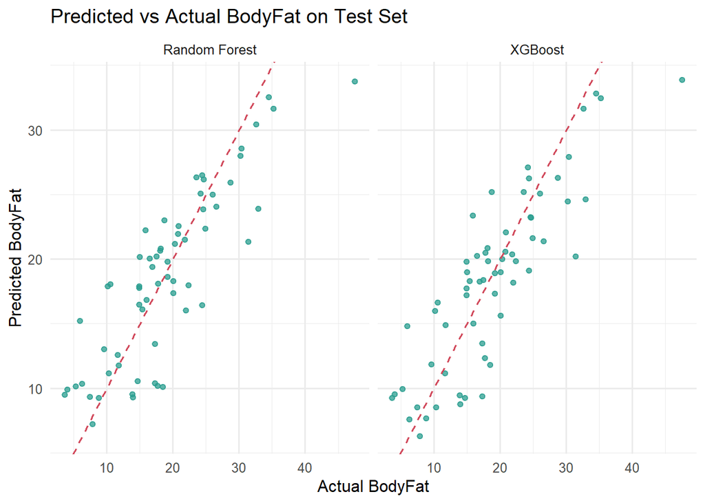

```r
# Predicted vs actual scatter plot for each model
rf_preds <- collect_predictions(rf_last) %>% mutate(model = "Random Forest")
xgb_preds <- collect_predictions(xgb_last) %>% mutate(model = "XGBoost")

preds_all <- bind_rows(rf_preds, xgb_preds)

ggplot(preds_all, aes(x = BodyFat, y = .pred)) +
  geom_point(alpha = 0.75, color = "#2A9D8F") +
  geom_abline(slope = 1, intercept = 0, linetype = "dashed", color = "#D1495B") +
  facet_wrap(~ model) +
  labs(
    title = "Predicted vs Actual BodyFat on Test Set",
    x = "Actual BodyFat",
    y = "Predicted BodyFat"
  ) +
  theme_minimal(base_size = 12)
```

Interpretation: - Points closer to the dashed 45-degree line indicate better predictions. - Compare spread around the line across panels to judge which tuned model generalizes better.

## 7.7 Variable Importance (Top 10 Features)

```r
# Fit finalized workflows on training data so we can inspect model internals
rf_fit <- fit(final_rf_workflow, data = train_data)
xgb_fit <- fit(final_xgb_workflow, data = train_data)

rf_engine <- extract_fit_engine(rf_fit)
xgb_engine <- extract_fit_engine(xgb_fit)
```

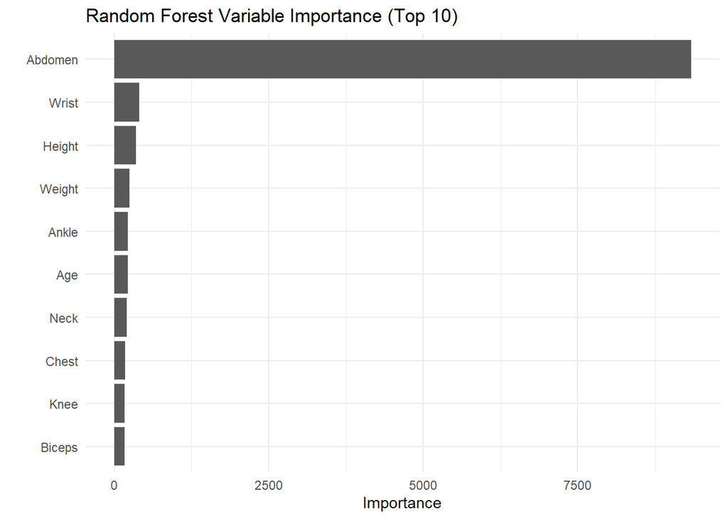

```r
# Random Forest variable importance
vip::vip(rf_engine, num_features = 10) +
  labs(title = "Random Forest Variable Importance (Top 10)") +
  theme_minimal(base_size = 11)
```

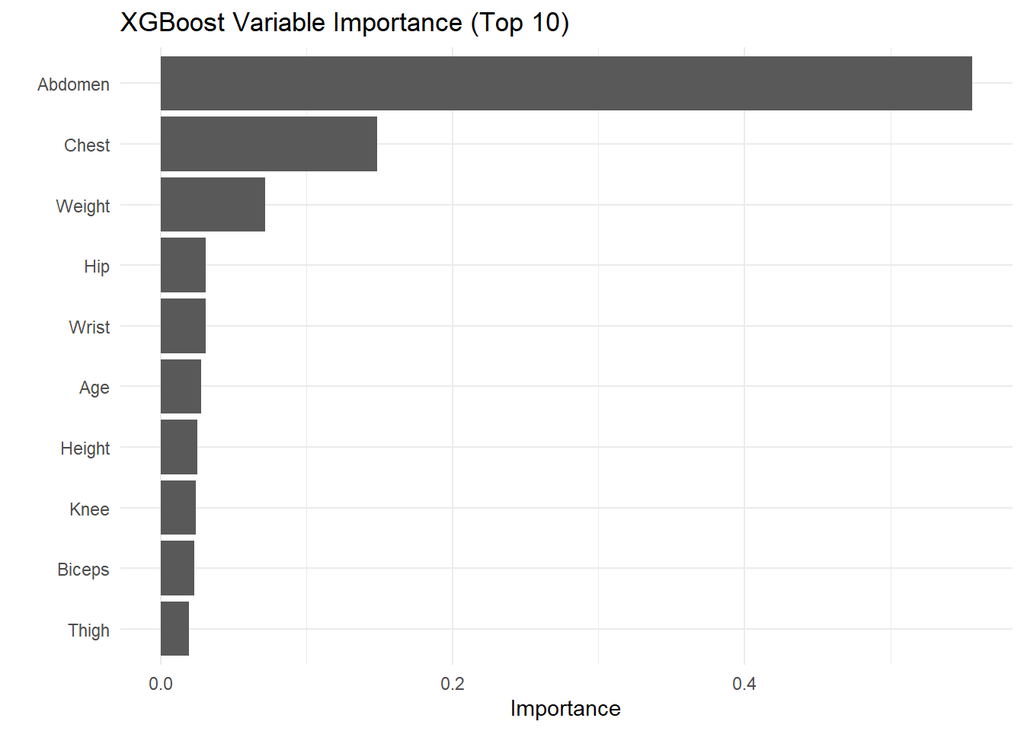

```r
# XGBoost variable importance
vip::vip(xgb_engine, num_features = 10) +
  labs(title = "XGBoost Variable Importance (Top 10)") +
  theme_minimal(base_size = 11)
```

```r
# Tabular importance to inspect ranking of Abdomen explicitly
rf_vi <- vip::vi(rf_engine) %>% mutate(model = "Random Forest")
xgb_vi <- vip::vi(xgb_engine) %>% mutate(model = "XGBoost")

bind_rows(rf_vi, xgb_vi) %>%
  group_by(model) %>%
  arrange(desc(Importance), .by_group = TRUE) %>%
  slice_head(n = 10) %>%
  ungroup()
```

```
# A tibble: 20 × 3
   Variable Importance model
   <chr>         <dbl> <chr>
 1 Abdomen   9335.     Random Forest
 2 Wrist      405.     Random Forest
 3 Height     348.     Random Forest
 4 Weight     250.     Random Forest
 5 Ankle      221.     Random Forest
 6 Age        217.     Random Forest
 7 Neck       201.     Random Forest
 8 Chest      180.     Random Forest
 9 Knee       172.     Random Forest
10 Biceps     165.     Random Forest
11 Abdomen      0.556  XGBoost
12 Chest        0.148  XGBoost
13 Weight       0.0715 XGBoost
14 Hip          0.0312 XGBoost
15 Wrist        0.0311 XGBoost
16 Age          0.0279 XGBoost
17 Height       0.0252 XGBoost
18 Knee         0.0243 XGBoost
19 Biceps       0.0231 XGBoost
20 Thigh        0.0193 XGBoost
```

Discussion: - `Abdomen` appears at or near rank 1 in both models. - This aligns with prior EDA that central body circumference has the strongest relationship with body fat.

## 7.8 Cleanup

```r
stopCluster(cl)
registerDoSEQ()
```